# a1

**Assignment 1:**

Gurjot Singh (B00811724) Bhavneet Kaur Sachdeva (B00809769)

**Question 1:** *a* The dataset is Zomato Bangalore Dataset which contains the infomration about various restaurants in Bangalore. The attributes contain the values like the dishes_liked, the cuisines it is famous for, the type of restaurant it is mostly considered, for example, Cafe or casual dining or a buffet restaurant. It also contains the reviews of people and the approx cost for 2 people in that restaurant. This dataset also contains information about the location and the neighborhood the restaurant is located in.

**Question 2** *a: Load the dataset*

```python
import pandas as pd
df = pd.read_csv("zomato.csv")
df
```

|  | url | address | name | online_order | book_table | rate | votes | phone | location | rest_type | dish_liked | cuisines | approx_cost(for two people) | reviews_list | menu_item | listed_in(type) | listed_in(city) |
| --- | --- | --- | --- | --- | --- | --- | --- | --- | --- | --- | --- | --- | --- | --- | --- | --- | --- |
| 0 | https://www.zomato.com/bangalore/jalsa-banasha... | 942, 21st Main Road, 2nd Stage, Banashankari, ... | Jalsa | Yes | Yes | 4.1/5 | 775 | 080 42297555\r\n+91 9743772233 | Banashankari | Casual Dining | Pasta, Lunch Buffet, Masala Papad, Paneer Laja... | North Indian, Mughlai, Chinese | 800 | [('Rated 4.0', 'RATED\n A beautiful place to ... | [] | Buffet | Banashankari |
| 1 | https://www.zomato.com/bangalore/spice-elephan... | 2nd Floor, 80 Feet Road, Near Big Bazaar, 6th ... | Spice Elephant | Yes | No | 4.1/5 | 787 | 080 41714161 | Banashankari | Casual Dining | Momos, Lunch Buffet, Chocolate Nirvana, Thai G... | Chinese, North Indian, Thai | 800 | [('Rated 4.0', 'RATED\n Had been here for din... | [] | Buffet | Banashankari |
| 2 | https://www.zomato.com/SanchurroBangalore?cont... | 1112, Next to KIMS Medical College, 17th Cross... | San Churro Cafe | Yes | No | 3.8/5 | 918 | +91 9663487993 | Banashankari | Cafe, Casual Dining | Churros, Cannelloni, Minestrone Soup, Hot Choc... | Cafe, Mexican, Italian | 800 | [('Rated 3.0', "RATED\n Ambience is not that ... | [] | Buffet | Banashankari |
| 3 | https://www.zomato.com/bangalore/addhuri-udupi... | 1st Floor, Annakuteera, 3rd Stage, Banashankar... | Addhuri Udupi Bhojana | No | No | 3.7/5 | 88 | +91 9620009302 | Banashankari | Quick Bites | Masala Dosa | South Indian, North Indian | 300 | [('Rated 4.0', "RATED\n Great food and proper... | [] | Buffet | Banashankari |
| 4 | https://www.zomato.com/bangalore/grand-village... | 10, 3rd Floor, Lakshmi Associates, Gandhi Baza... | Grand Village | No | No | 3.8/5 | 166 | +91 8026612447\r\n+91 9901210005 | Basavanagudi | Casual Dining | Panipuri, Gol Gappe | North Indian, Rajasthani | 600 | [('Rated 4.0', 'RATED\n Very good restaurant ... | [] | Buffet | Banashankari |
| 5 | https://www.zomato.com/bangalore/timepass-dinn... | 37, 5-1, 4th Floor, Bosco Court, Gandhi Bazaar... | Timepass Dinner | Yes | No | 3.8/5 | 286 | +91 9980040002\r\n+91 9980063005 | Basavanagudi | Casual Dining | Onion Rings, Pasta, Kadhai Paneer, Salads, Sal... | North Indian | 600 | [('Rated 3.0', 'RATED\n Food 3/5\nAmbience 3/... | [] | Buffet | Banashankari |
| 6 | https://www.zomato.com/bangalore/rosewood-inte... | 19/1, New Timberyard Layout, Beside Satellite ... | Rosewood International Hotel - Bar & Restaurant | No | No | 3.6/5 | 8 | +91 9731716688\r\n080 26740366 | Mysore Road | Casual Dining | NaN | North Indian, South Indian, Andhra, Chinese | 800 | [('Rated 5.0', 'RATED\n Awesome food ??Great ... | [] | Buffet | Banashankari |
| 7 | https://www.zomato.com/bangalore/onesta-banash... | 2469, 3rd Floor, 24th Cross, Opposite BDA Comp... | Onesta | Yes | Yes | 4.6/5 | 2556 | 080 48653961\r\n080 48655715 | Banashankari | Casual Dining, Cafe | Farmhouse Pizza, Chocolate Banana, Virgin Moji... | Pizza, Cafe, Italian | 600 | [('Rated 5.0', 'RATED\n I personally really l... | [] | Cafes | Banashankari |
| 8 | https://www.zomato.com/bangalore/penthouse-caf... | 1, 30th Main Road, 3rd Stage, Banashankari, Ba... | Penthouse Cafe | Yes | No | 4.0/5 | 324 | +91 8884135549\r\n+91 9449449316 | Banashankari | Cafe | Pizza, Mocktails, Coffee, Nachos, Salad, Pasta... | Cafe, Italian, Continental | 700 | [('Rated 3.0', "RATED\n I had been to this pl... | [] | Cafes | Banashankari |
| 9 | https://www.zomato.com/bangalore/smacznego-ban... | 2470, 21 Main Road, 25th Cross, Banashankari, ... | Smacznego | Yes | No | 4.2/5 | 504 | +91 9945230807\r\n+91 9743804471 | Banashankari | Cafe | Waffles, Pasta, Coleslaw Sandwich, Choco Waffl... | Cafe, Mexican, Italian, Momos, Beverages | 550 | [('Rated 4.0', "RATED\n Easy to locate\nVFM 3... | [] | Cafes | Banashankari |
| 10 | https://www.zomato.com/bangalore/caf%C3%A9-dow... | 12,29 Near PES University Back Gate, D'Souza N... | CafÃÂÃÂÃÂÃÂ© Down The A... | Yes | No | 4.1/5 | 402 | 080 26724489\r\n+91 7406048982 | Banashankari | Cafe | Waffles, Pasta, Crispy Chicken, Honey Chilli C... | Cafe | 500 | [('Rated 4.0', 'RATED\n We ended up here on a... | [] | Cafes | Banashankari |
| 11 | https://www.zomato.com/bangalore/cafe-shuffle-... | 941, 3rd FLOOR, 21st Main, 22nd Cross, Banasha... | Cafe Shuffle | Yes | Yes | 4.2/5 | 150 | +91 9742166777 | Banashankari | Cafe | Mocktails, Peri Fries, Lasagne, Pizza, Chicken... | Cafe, Italian, Continental | 600 | [('Rated 1.0', "RATED\n \n\nHorrible. Not even... | [] | Cafes | Banashankari |
| 12 | https://www.zomato.com/bangalore/the-coffee-sh... | 6th Block, 3rd Stage, Banashankari, Bangalore | The Coffee Shack | Yes | Yes | 4.2/5 | 164 | +91 9731644212 | Banashankari | Cafe | Coffee, Spaghetti, Pancakes, Nachos, Pasta, Sa... | Cafe, Chinese, Continental, Italian | 500 | [('Rated 4.0', "RATED\n Food - 4/5\nAmbience ... | [] | Cafes | Banashankari |
| 13 | https://www.zomato.com/bangalore/caf-eleven-ba... | 111, Sapphire Toys Building, 100 Feet Ring Roa... | Caf-Eleven | No | No | 4.0/5 | 424 | 080 49577715 | Banashankari | Cafe | Sandwich, Omelette, Ice Tea, Virgin Mojito, Ho... | Cafe, Continental | 450 | [('Rated 2.0', "RATED\n This is a hookah cafe... | [] | Cafes | Banashankari |
| 14 | https://www.zomato.com/SanchurroBangalore?cont... | 1112, Next to KIMS Medical College, 17th Cross... | San Churro Cafe | Yes | No | 3.8/5 | 918 | +91 9663487993 | Banashankari | Cafe, Casual Dining | Churros, Cannelloni, Minestrone Soup, Hot Choc... | Cafe, Mexican, Italian | 800 | [('Rated 3.0', "RATED\n Ambience is not that ... | [] | Cafes | Banashankari |
| 15 | https://www.zomato.com/bangalore/cafe-vivacity... | 2303, 21st Cross, K R Road, 2nd Stage, Banasha... | Cafe Vivacity | Yes | No | 3.8/5 | 90 | 080 26768182\r\n+91 9845704455 | Banashankari | Cafe | Garlic Bread, Burgers, Sandwiches, Pizza, Hot ... | Cafe | 650 | [('Rated 2.0', 'RATED\n Not so good place as ... | [] | Cafes | Banashankari |
| 16 | https://www.zomato.com/bangalore/catch-up-ino-... | 241, 4th Floor, 100 Feet Ring Road, Opposite K... | Catch-up-ino | Yes | No | 3.9/5 | 133 | +91 9972988038\r\n+91 9900121238 | Banashankari | Cafe | Momos, Mushroom Bruschettas, Jalapeno Cheeseba... | Cafe, Fast Food, Continental, Chinese, Momos | 800 | [('Rated 1.0', "RATED\n This place is right o... | [] | Cafes | Banashankari |
| 17 | https://www.zomato.com/bangalore/kirthis-birya... | 405, 24th Cross, 9th Main, 2nd Stage, Banashan... | Kirthi's Biryani | Yes | No | 3.8/5 | 144 | 080 26711554\r\n+91 9741406338 | Banashankari | Cafe | Pasta, Gelato, Garlic Bread, Mojito, Nachos, P... | Chinese, Cafe, Italian | 700 | [('Rated 3.0', "RATED\n New place.. though it... | [] | Cafes | Banashankari |
| 18 | https://www.zomato.com/bangalore/t3h-cafe-bana... | 504, CJ Venkata Das Road, Padmanabhangar, 2nd ... | T3H Cafe | No | No | 3.9/5 | 93 | +91 8884726600 | Banashankari | Cafe | Cheese Maggi, Peri Peri Fries, Pasta Arrabiata | Cafe, Italian, American | 300 | [('Rated 4.0', "RATED\n Happy to see such a c... | [] | Cafes | Banashankari |
| 19 | https://www.zomato.com/bangalore/360-atoms-res... | 47, 48 &49, 3Rd Floor, 21st Main Road, 2nd Sta... | 360 Atoms Restaurant And Cafe | Yes | No | 3.1/5 | 13 | +91 9880594520 | Banashankari | Cafe | NaN | Cafe, Chinese, Continental, Italian | 400 | [('Rated 5.0', 'RATED\n Friendly staffs , nic... | [] | Cafes | Banashankari |
| 20 | https://www.zomato.com/bangalore/the-vintage-c... | 146, 50 ft Road, 3rd Phase, 3rd Stage, Near Ka... | The Vintage Cafe | Yes | No | 3.0/5 | 62 | +91 9880016665\r\n+91 8217311687 | Banashankari | Cafe | Burgers, Caramel Milkshake, Iced Coffee, Iced Tea | Cafe, French, North Indian | 400 | [('Rated 2.0', "RATED\n This is a tiny cafÃ\... | [] | Cafes | Banashankari |
| 21 | https://www.zomato.com/bangalore/woodee-pizza-... | 3353, 2nd Cross, Opposite Auden School, Hosker... | Woodee Pizza | Yes | No | 3.7/5 | 180 | +91 7406822844 | Banashankari | Cafe | Pizza, Garlic Bread | Cafe, Pizza, Fast Food, Beverages | 500 | [('Rated 3.0', 'RATED\n Decided to take a bre... | [] | Cafes | Banashankari |
| 22 | https://www.zomato.com/bangalore/cafe-coffee-d... | SRF Complex, Near BDA Complex, Kathreguppe Mai... | Cafe Coffee Day | No | No | 3.6/5 | 28 | 080 32486296 | Banashankari | Cafe | NaN | Cafe, Fast Food | 900 | [('Rated 4.0', 'RATED\n This outlet is better... | [] | Cafes | Banashankari |
| 23 | https://www.zomato.com/bangalore/my-tea-house-... | 224/Y, 4th Phase, 7th Block, 100 Feet Ring Roa... | My Tea House | Yes | No | 3.6/5 | 62 | 080 65975430\r\n+91 7337733798 | Banashankari | Quick Bites, Cafe | Pasta, Iced Tea | Italian, Fast Food, Cafe, European | 600 | [('Rated 4.0', "RATED\n So, went here with fr... | [] | Cafes | Banashankari |
| 24 | https://www.zomato.com/bangalore/hide-out-cafe... | 775/1, Opposite Gupta Collage, 7th Block, 3rd ... | Hide Out Cafe | No | No | 3.7/5 | 31 | +91 9901481185 | Banashankari | Cafe | NaN | Cafe | 300 | [('Rated 4.0', 'RATED\n The food was quite go... | [] | Cafes | Banashankari |
| 25 | https://www.zomato.com/bangalore/cafe-nova-ban... | 101, Water Tank Road, 2nd Block, 3rd Stage, Ba... | CAFE NOVA | No | No | 3.2/5 | 11 | +91 8971090261 | Banashankari | Cafe | NaN | Cafe, Bakery | 600 | [('Rated 1.0', "RATED\n No ventilation. Smoke... | [] | Cafes | Banashankari |
| 26 | https://www.zomato.com/bangalore/coffee-tindi-... | 27th Cross Rd, Banashankari Stage II, Banashan... | Coffee Tindi | Yes | No | 3.8/5 | 75 | +91 9945758046 | Banashankari | Cafe, Quick Bites | NaN | Cafe, South Indian | 200 | [('Rated 5.0', 'RATED\n please provide some e... | [] | Cafes | Banashankari |
| 27 | https://www.zomato.com/bangalore/sea-green-caf... | 1036, Srinidhi Plaza, 3rd floor, Above Nilgiri... | Sea Green Cafe | No | No | 3.3/5 | 4 | +91 9008628448 | Banashankari | Cafe | NaN | Cafe, Fast Food, Beverages | 500 | [('Rated 5.0', 'RATED\n Newly opened cafe nea... | [] | Cafes | Banashankari |
| 28 | https://www.zomato.com/bangalore/cuppa-1-banas... | 940, Shantha Complex, 20th Main, 2nd Stage, Ba... | Cuppa | No | No | 3.3/5 | 23 | +91 9591111123 | Banashankari | Cafe | NaN | Cafe, Fast Food | 550 | [('Rated 1.5', 'RATED\n This place was good t... | [] | Cafes | Banashankari |
| 29 | https://www.zomato.com/bangalore/srinathjis-ca... | 112, Bull Temple Road,next to more Basavanagud... | Srinathji's Cafe | No | No | 3.8/5 | 148 | 080 26600704\r\n+91 9342593424 | Basavanagudi | Casual Dining, Cafe | Paratha, Sandwich, Chilli Idli, Noodles, Sandw... | North Indian, Cafe, Chinese, Fast Food | 550 | [('Rated 5.0', 'RATED\n No words for the pane... | [] | Cafes | Banashankari |
| ... | ... | ... | ... | ... | ... | ... | ... | ... | ... | ... | ... | ... | ... | ... | ... | ... | ... |
| 51687 | https://www.zomato.com/bangalore/red-rhino-whi... | 4th Floor, Uptown Square, Seegehalli, Near All... | Red Rhino | Yes | Yes | 4.4 /5 | 1980 | 080 49652108 | Whitefield | Microbrewery, Pub | Beer, Margarita, Long Island Iced Tea, Cocktai... | Continental, Mediterranean, South Indian, Nort... | 1,700 | [('Rated 4.0', 'RATED\n Red Rhino is a Brewer... | ['Hangover', 'Smoking Hot Red Rhino Chilli Chi... | Pubs and bars | Whitefield |
| 51688 | https://www.zomato.com/bangalore/ji-hazoor-whi... | TR 9, 4th Floor, Plot 95, EPIP Zone, Near Vaid... | Ji Hazoor | Yes | Yes | 4.0 /5 | 2856 | 080 49652519 | Whitefield | Casual Dining, Bar | Chicken Salad, Mocktails, Mutton Curry, Chicke... | Mughlai, North Indian, Biryani, Afghan | 1,100 | [('Rated 4.0', 'RATED\n Was there on last Wed... | ['Dal Tadka', 'Dal Makhani', 'Paneer Tikka Mas... | Pubs and bars | Whitefield |
| 51689 | https://www.zomato.com/bangalore/hq-whitefield... | 75, Inorbit Mall, EPIP Area, Road 7, Whitefiel... | HQ | No | Yes | 4.1 /5 | 564 | +91 9945577195\n+91 9886144774 | Whitefield | Casual Dining, Bar | Mocktails, Pizza, Crispy Chicken, Beer, Nachos... | North Indian, Italian, Finger Food, Continental | 1,000 | [('Rated 3.0', "RATED\n HQ is located at grou... | [] | Pubs and bars | Whitefield |
| 51690 | https://www.zomato.com/bangalore/biere-societe... | 223-1, ITPL Main Road, Sadarmangala, KR Puram ... | Biere Societee | No | Yes | 4.2 /5 | 320 | +91 8296412555\n080 28413555 | Whitefield | Pub | Tempura Prawns, Cocktails, Noodles, Masala Pea... | Asian, Continental, European | 1,500 | [('Rated 3.0', 'RATED\n Went with Team on Thu... | [] | Pubs and bars | Whitefield |
| 51691 | https://www.zomato.com/bangalore/uno-chicago-b... | Shop FB-02, Upper Ground Floor, Prestige Shant... | Uno Chicago Bar & Grill | No | Yes | 4.2 /5 | 156 | +91 9667540036\n+91 7042349751 | Whitefield | Bar, Casual Dining | Deep Dish Pizza, Mocktails, Burgers, Onion Rin... | American, Italian | 1,800 | [('Rated 4.0', "RATED\n Had been here for lun... | [] | Pubs and bars | Whitefield |
| 51692 | https://www.zomato.com/bangalore/amoeba-sports... | Third Floor, Ascendas Park Square, ITPL Main R... | Amoeba Sports Bar | Yes | Yes | 3.9 /5 | 578 | +91 9845555740\n+91 9886743857 | Whitefield | Lounge, Bar | Pasta, Fish, Beer, Chicken Wings, Mocktails, G... | Continental, Chinese | 1,000 | [('Rated 3.0', 'RATED\n Amoeba is affordable ... | [] | Pubs and bars | Whitefield |
| 51693 | https://www.zomato.com/bangalore/one-for-the-r... | 87/2A & 87/3, SH 35, Seegehalli, Whitefield, B... | One For The Road | Yes | Yes | 4.1 /5 | 137 | 080 49652780 | Whitefield | Bar | Cocktails, Pasta, Fish | Continental, North Indian, Finger Food | 1,200 | [('Rated 4.0', 'RATED\n Had been there on a S... | ['Chicken Manchow Soup', 'Chicken Lollipop', '... | Pubs and bars | Whitefield |
| 51694 | https://www.zomato.com/WhitefieldSocial?contex... | 29, Ground Floor, Phoenix Market City, Whitefi... | Whitefield Social | Yes | No | 4.1 /5 | 2773 | +91 8049626661\n+91 9886252234 | Whitefield | Pub | Cocktails, Chicken Kebab, Murgh Ghee Roast, Vi... | American, North Indian, Chinese, Finger Food, ... | 1,500 | [('Rated 2.0', 'RATED\n Honestly speaking it ... | ['Chilli Paneer Black Pepper China Box', 'Chil... | Pubs and bars | Whitefield |
| 51695 | https://www.zomato.com/bangalore/the-whitefiel... | The Waverly Hotels, Whitefield, Bangalore | The Whitefield Arms Pub & Microbrewery | Yes | Yes | 4.2 /5 | 1113 | 080 49653340 | Whitefield | Pub, Microbrewery | Beer, Chicken Tikka, Cosmopolitan, Burgers, Co... | British, Continental, BBQ | 1,600 | [('Rated 4.0', "RATED\n I never knew of this ... | [] | Pubs and bars | Whitefield |
| 51696 | https://www.zomato.com/bangalore/the-irish-hou... | TF-01A, Level 3, VR Mall, Mahadevpura, Whitefi... | The Irish House | No | Yes | 4.3 /5 | 1776 | +91 8317403477\n+91 9886634664 | Whitefield | Casual Dining, Pub | Beer, Cocktails, Burgers, Chicken Nachos, Mock... | European, American | 1,700 | [('Rated 4.0', 'RATED\n Nice place to grab a ... | [] | Pubs and bars | Whitefield |
| 51697 | https://www.zomato.com/bangalore/shizusan-shop... | Level 2, Phoenix Marketcity, Mahadevpura, Whit... | Shizusan Shophouse & Bar | Yes | Yes | 4.4 /5 | 1313 | 080 67266655\n080 49626655 | Whitefield | Casual Dining, Bar | California Roll, Cocktails, Mocktails, Maki Ro... | Asian, Japanese, Vietnamese, Korean, Chinese, ... | 1,800 | [('Rated 3.0', 'RATED\n Wanted to try this pl... | [] | Pubs and bars | Whitefield |
| 51698 | https://www.zomato.com/bangalore/kava-kitchen-... | 3-A1, Kundanahalli Main Road, Mahadevpura, Opp... | Kava Kitchen & Bar - Fairfield by Marriott | No | No | 3.9 /5 | 74 | 080 68141414 | Whitefield | Casual Dining, Bar | Dal Halwa | North Indian, South Indian, Continental, Ameri... | 1,200 | [('Rated 4.0', 'RATED\n Loved the food, thoug... | [] | Pubs and bars | Whitefield |
| 51699 | https://www.zomato.com/bangalore/harrys-bar-ca... | S-10, Level 2, Phoenix Market City, Whitefield... | Harry's Bar + Cafe | Yes | Yes | 4.1 /5 | 1218 | +91 7676924054\n+91 9137153744 | Whitefield | Pub | Cocktails, Beer, Long Island Iced Tea, Pasta, ... | Asian, American, Mexican | 1,200 | [('Rated 4.0', 'RATED\n The first thing that ... | [] | Pubs and bars | Whitefield |
| 51700 | https://www.zomato.com/bangalore/bar-bar-white... | Level 2, Phoenix Marketcity, Whitefield, Banga... | BAR BAR | No | Yes | 4.1 /5 | 1003 | +91 7338630404\n+91 8067266651 | Whitefield | Bar, Casual Dining | Mocktails, Cocktails, Pizza, Chicken Tikka, Na... | Continental, North Indian, Italian | 1,500 | [('Rated 4.0', "RATED\n In an increasingly ov... | [] | Pubs and bars | Whitefield |
| 51701 | https://www.zomato.com/bangalore/the-beer-cafe... | Unit 4A - 4B, Upper Ground Floor, VR Bengaluru... | The Beer Cafe | Yes | Yes | 4.1 /5 | 673 | +91 8929188573 | Whitefield | Pub | Cocktails, Wheat Beer, Bruschettas, Pasta, Bur... | Finger Food, North Indian, Chinese, Italian | 1,400 | [('Rated 2.0', "RATED\n We went out to this p... | [] | Pubs and bars | Whitefield |
| 51702 | https://www.zomato.com/bangalore/pablos-gastro... | 2, Graphite India Road, Doddanekundi Industria... | Pablo's Gastrobar | No | No | 4.0 /5 | 1094 | 00 9108214702 | Whitefield | Bar | Cocktails, Beer, Pizza, Long Island Iced Tea, ... | Finger Food, American, Asian, Italian | 1,450 | [('Rated 4.0', 'RATED\n A good place to dine.... | [] | Pubs and bars | Whitefield |
| 51703 | https://www.zomato.com/bangalore/olivers-pub-d... | ITPL Ascendas Park Square Mall, ITPL, First Fl... | Oliver's Pub & Diner | Yes | Yes | 3.9 /5 | 548 | +91 8043691111\n+91 8028026519 | Whitefield | Pub, Casual Dining | Pizza, Beer, Cocktails, Nachos, Pasta, Moo Bur... | Finger Food, American, Continental, Burger, Pizza | 1,500 | [('Rated 4.0', "RATED\n I had :-\n\n1. Italia... | [] | Pubs and bars | Whitefield |
| 51704 | https://www.zomato.com/bangalore/smaaash-white... | 2nd Floor, Phoenix Market City, Whitefield, Ba... | Smaaash | No | Yes | 4.0 /5 | 189 | +91 9900069474\n+91 7899644468 | Whitefield | Casual Dining, Pub | Pizza, Beer | North Indian, Pizza, Chinese | 1,500 | [('Rated 3.0', 'RATED\n Like this place for z... | [] | Pubs and bars | Whitefield |
| 51705 | https://www.zomato.com/bangalore/izakaya-gastr... | 2nd Floor, Iona, Virginia Mall, Whitefield Mai... | Izakaya Gastro Pub | Yes | Yes | 3.8 /5 | 128 | +91 7625087121\n+91 8050587483 | Whitefield | Bar, Casual Dining | Beer, Chicken Guntur, Paneer Tikka, Fish, Nood... | North Indian, Continental, Mediterranean | 1,200 | [('Rated 3.0', "RATED\n Nice place to hangout... | [] | Pubs and bars | Whitefield |
| 51706 | https://www.zomato.com/bangalore/red-glow-whit... | Poornima Complex, Dodsworth Layout, Whitefield... | Red Glow | No | No | 3.7 /5 | 27 | +91 9740571131 | Whitefield | Pub | NaN | North Indian, Continental | 1,200 | [('Rated 5.0', 'RATED\n Excellent place had n... | [] | Pubs and bars | Whitefield |
| 51707 | https://www.zomato.com/bangalore/m-bar-bengalu... | Bengaluru Marriott Hotel, 75, 8th Road, EPIP A... | M Bar - Bengaluru Marriott Hotel Whitefield | No | No | 3.9 /5 | 77 | 080 49435000 | Whitefield | Fine Dining, Bar | Rooftop Ambience | Finger Food | 2,000 | [('Rated 4.0', 'RATED\n Went there post dinne... | [] | Pubs and bars | Whitefield |
| 51708 | https://www.zomato.com/bangalore/keys-cafe-key... | Keys Hotel, 6, 1st Phase Industrial Area, Near... | Keys Cafe - Keys Hotel | No | No | 2.8 /5 | 161 | 080 39451000\n+91 8884038484 | Whitefield | Casual Dining, Bar | Salads, Coffee, Breakfast Buffet, Halwa, Chick... | Chinese, Continental, North Indian | 1,200 | [('Rated 3.0', 'RATED\n Place is good not tha... | [] | Pubs and bars | Whitefield |
| 51709 | https://www.zomato.com/bangalore/the-farm-hous... | 136, SAP Labs India, KIADB Export Promotion In... | The Farm House Bar n Grill | No | No | 3.7 /5 | 34 | +91 9980121279\n+91 9900240646 | Whitefield | Casual Dining, Bar | NaN | North Indian, Continental | 800 | [('Rated 4.0', 'RATED\n Ambience- Big and spa... | [] | Pubs and bars | Whitefield |
| 51710 | https://www.zomato.com/bangalore/topsy-turvey-... | 2E2, 4th Cross Road, Devasandra Industrial Est... | Topsy Turvey | No | No | NaN | 0 | +91 9148155994 | Whitefield | Bar | NaN | Finger Food | 900 | [('Rated 4.0', "RATED\n A divine joint for Fl... | [] | Pubs and bars | Whitefield |
| 51711 | https://www.zomato.com/bangalore/bhagini-2-whi... | 139/C1, Next To GR Tech Park, Pattandur Agraha... | Bhagini | No | No | 2.5 /5 | 81 | 080 65951222 | Whitefield | Casual Dining, Bar | Biryani, Andhra Meal | Andhra, South Indian, Chinese, North Indian | 800 | [('Rated 4.0', 'RATED\n A fine place to chill... | [] | Pubs and bars | Whitefield |
| 51712 | https://www.zomato.com/bangalore/best-brews-fo... | Four Points by Sheraton Bengaluru, 43/3, White... | Best Brews - Four Points by Sheraton Bengaluru... | No | No | 3.6 /5 | 27 | 080 40301477 | Whitefield | Bar | NaN | Continental | 1,500 | [('Rated 5.0', "RATED\n Food and service are ... | [] | Pubs and bars | Whitefield |
| 51713 | https://www.zomato.com/bangalore/vinod-bar-and... | Number 10, Garudachar Palya, Mahadevapura, Whi... | Vinod Bar And Restaurant | No | No | NaN | 0 | +91 8197675843 | Whitefield | Bar | NaN | Finger Food | 600 | [] | [] | Pubs and bars | Whitefield |
| 51714 | https://www.zomato.com/bangalore/plunge-sherat... | Sheraton Grand Bengaluru Whitefield Hotel & Co... | Plunge - Sheraton Grand Bengaluru Whitefield H... | No | No | NaN | 0 | NaN | Whitefield | Bar | NaN | Finger Food | 2,000 | [] | [] | Pubs and bars | Whitefield |
| 51715 | https://www.zomato.com/bangalore/chime-sherato... | Sheraton Grand Bengaluru Whitefield Hotel & Co... | Chime - Sheraton Grand Bengaluru Whitefield Ho... | No | Yes | 4.3 /5 | 236 | 080 49652769 | ITPL Main Road, Whitefield | Bar | Cocktails, Pizza, Buttermilk | Finger Food | 2,500 | [('Rated 4.0', 'RATED\n Nice and friendly pla... | [] | Pubs and bars | Whitefield |
| 51716 | https://www.zomato.com/bangalore/the-nest-the-... | ITPL Main Road, KIADB Export Promotion Industr... | The Nest - The Den Bengaluru | No | No | 3.4 /5 | 13 | +91 8071117272 | ITPL Main Road, Whitefield | Bar, Casual Dining | NaN | Finger Food, North Indian, Continental | 1,500 | [('Rated 5.0', 'RATED\n Great ambience , look... | [] | Pubs and bars | Whitefield |

51717 rows × 17 columns

```python
for i in df:
    print (i, df[i].nunique())
```

```
url 51717
address 11495
name 8792
online_order 2
book_table 2
rate 64
votes 2328
phone 14926
location 93
rest_type 93
dish_liked 5271
cuisines 2723
approx_cost(for two people) 70
reviews_list 22513
menu_item 9098
listed_in(type) 7
listed_in(city) 30
```

```python
df['name'] = df["name"].apply(lambda x: ''.join([" " if ord(i) < 32 or ord(i) > 126 else i for i in x]))
```

*b Plot the data and find the trends in the data.* The data has been plotted for various columns. But as it can be seen from the unique values in each column from the above output, values for url,phones have not been plotted. As all urls are different, it does not make any sense to plot them or even use them in our further steps. Similarly, phone number does not have any effect on our data or the model we intend to build on. Hence, it does not make sense to use it further. Now, from plotting the graphs below, we can see that name has many unique values and cannot be plotted. But, it also gives us an idea about how many restaurants are famous with a lot of outlets in the city. This lets us know about the chain of outlets available in Bangalore and the popularity of different restaurants.

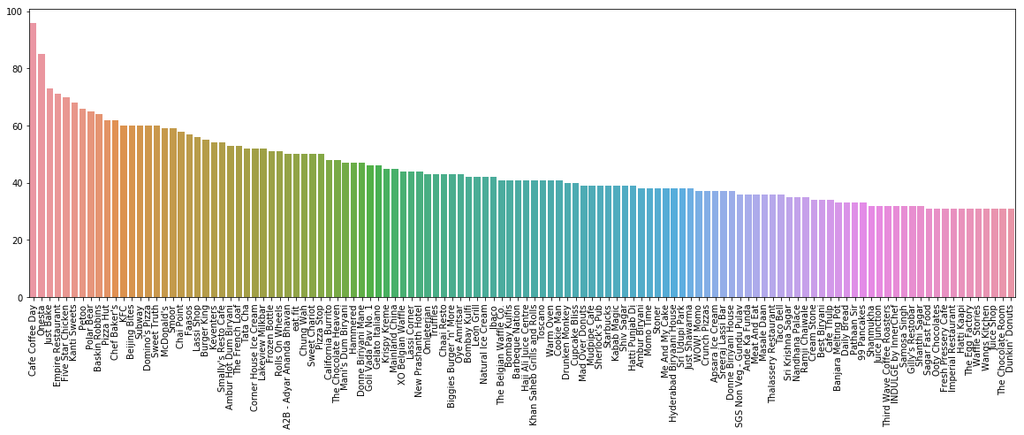

```python
import seaborn
import matplotlib.pyplot as plt
%matplotlib inline
plt.figure(figsize=(20, 6))
list1 = []
list2 = []
for val, cnt in df['name'].value_counts().iteritems():
    if cnt>30:
        list1.append(val)
        list2.append(cnt)
name_bar = seaborn.barplot(x=list1, y=list2)
plt.xticks(rotation='vertical')
```

```python
df['rate'] = df['rate'].str.split("/")
df['rating'] = df.rate.str[0]
df['rate'] = df['rating']
```

```python
import numpy as np
df['rate'] = df['rate'].replace('NEW', np.NaN)
df['rate'] = df['rate'].replace(np.NaN, '-')
df['rate'] = df['rate'].replace('-','0.0')
df
```

|  | url | address | name | online_order | book_table | rate | votes | phone | location | rest_type | dish_liked | cuisines | approx_cost(for two people) | reviews_list | menu_item | listed_in(type) | listed_in(city) | rating |
| --- | --- | --- | --- | --- | --- | --- | --- | --- | --- | --- | --- | --- | --- | --- | --- | --- | --- | --- |
| 0 | https://www.zomato.com/bangalore/jalsa-banasha... | 942, 21st Main Road, 2nd Stage, Banashankari, ... | Jalsa | Yes | Yes | 4.1 | 775 | 080 42297555\r\n+91 9743772233 | Banashankari | Casual Dining | Pasta, Lunch Buffet, Masala Papad, Paneer Laja... | North Indian, Mughlai, Chinese | 800 | [('Rated 4.0', 'RATED\n A beautiful place to ... | [] | Buffet | Banashankari | 4.1 |
| 1 | https://www.zomato.com/bangalore/spice-elephan... | 2nd Floor, 80 Feet Road, Near Big Bazaar, 6th ... | Spice Elephant | Yes | No | 4.1 | 787 | 080 41714161 | Banashankari | Casual Dining | Momos, Lunch Buffet, Chocolate Nirvana, Thai G... | Chinese, North Indian, Thai | 800 | [('Rated 4.0', 'RATED\n Had been here for din... | [] | Buffet | Banashankari | 4.1 |
| 2 | https://www.zomato.com/SanchurroBangalore?cont... | 1112, Next to KIMS Medical College, 17th Cross... | San Churro Cafe | Yes | No | 3.8 | 918 | +91 9663487993 | Banashankari | Cafe, Casual Dining | Churros, Cannelloni, Minestrone Soup, Hot Choc... | Cafe, Mexican, Italian | 800 | [('Rated 3.0', "RATED\n Ambience is not that ... | [] | Buffet | Banashankari | 3.8 |
| 3 | https://www.zomato.com/bangalore/addhuri-udupi... | 1st Floor, Annakuteera, 3rd Stage, Banashankar... | Addhuri Udupi Bhojana | No | No | 3.7 | 88 | +91 9620009302 | Banashankari | Quick Bites | Masala Dosa | South Indian, North Indian | 300 | [('Rated 4.0', "RATED\n Great food and proper... | [] | Buffet | Banashankari | 3.7 |
| 4 | https://www.zomato.com/bangalore/grand-village... | 10, 3rd Floor, Lakshmi Associates, Gandhi Baza... | Grand Village | No | No | 3.8 | 166 | +91 8026612447\r\n+91 9901210005 | Basavanagudi | Casual Dining | Panipuri, Gol Gappe | North Indian, Rajasthani | 600 | [('Rated 4.0', 'RATED\n Very good restaurant ... | [] | Buffet | Banashankari | 3.8 |
| 5 | https://www.zomato.com/bangalore/timepass-dinn... | 37, 5-1, 4th Floor, Bosco Court, Gandhi Bazaar... | Timepass Dinner | Yes | No | 3.8 | 286 | +91 9980040002\r\n+91 9980063005 | Basavanagudi | Casual Dining | Onion Rings, Pasta, Kadhai Paneer, Salads, Sal... | North Indian | 600 | [('Rated 3.0', 'RATED\n Food 3/5\nAmbience 3/... | [] | Buffet | Banashankari | 3.8 |
| 6 | https://www.zomato.com/bangalore/rosewood-inte... | 19/1, New Timberyard Layout, Beside Satellite ... | Rosewood International Hotel - Bar & Restaurant | No | No | 3.6 | 8 | +91 9731716688\r\n080 26740366 | Mysore Road | Casual Dining | NaN | North Indian, South Indian, Andhra, Chinese | 800 | [('Rated 5.0', 'RATED\n Awesome food ??Great ... | [] | Buffet | Banashankari | 3.6 |
| 7 | https://www.zomato.com/bangalore/onesta-banash... | 2469, 3rd Floor, 24th Cross, Opposite BDA Comp... | Onesta | Yes | Yes | 4.6 | 2556 | 080 48653961\r\n080 48655715 | Banashankari | Casual Dining, Cafe | Farmhouse Pizza, Chocolate Banana, Virgin Moji... | Pizza, Cafe, Italian | 600 | [('Rated 5.0', 'RATED\n I personally really l... | [] | Cafes | Banashankari | 4.6 |
| 8 | https://www.zomato.com/bangalore/penthouse-caf... | 1, 30th Main Road, 3rd Stage, Banashankari, Ba... | Penthouse Cafe | Yes | No | 4.0 | 324 | +91 8884135549\r\n+91 9449449316 | Banashankari | Cafe | Pizza, Mocktails, Coffee, Nachos, Salad, Pasta... | Cafe, Italian, Continental | 700 | [('Rated 3.0', "RATED\n I had been to this pl... | [] | Cafes | Banashankari | 4.0 |
| 9 | https://www.zomato.com/bangalore/smacznego-ban... | 2470, 21 Main Road, 25th Cross, Banashankari, ... | Smacznego | Yes | No | 4.2 | 504 | +91 9945230807\r\n+91 9743804471 | Banashankari | Cafe | Waffles, Pasta, Coleslaw Sandwich, Choco Waffl... | Cafe, Mexican, Italian, Momos, Beverages | 550 | [('Rated 4.0', "RATED\n Easy to locate\nVFM 3... | [] | Cafes | Banashankari | 4.2 |
| 10 | https://www.zomato.com/bangalore/caf%C3%A9-dow... | 12,29 Near PES University Back Gate, D'Souza N... | Caf Down The A... | Yes | No | 4.1 | 402 | 080 26724489\r\n+91 7406048982 | Banashankari | Cafe | Waffles, Pasta, Crispy Chicken, Honey Chilli C... | Cafe | 500 | [('Rated 4.0', 'RATED\n We ended up here on a... | [] | Cafes | Banashankari | 4.1 |
| 11 | https://www.zomato.com/bangalore/cafe-shuffle-... | 941, 3rd FLOOR, 21st Main, 22nd Cross, Banasha... | Cafe Shuffle | Yes | Yes | 4.2 | 150 | +91 9742166777 | Banashankari | Cafe | Mocktails, Peri Fries, Lasagne, Pizza, Chicken... | Cafe, Italian, Continental | 600 | [('Rated 1.0', "RATED\n \n\nHorrible. Not even... | [] | Cafes | Banashankari | 4.2 |
| 12 | https://www.zomato.com/bangalore/the-coffee-sh... | 6th Block, 3rd Stage, Banashankari, Bangalore | The Coffee Shack | Yes | Yes | 4.2 | 164 | +91 9731644212 | Banashankari | Cafe | Coffee, Spaghetti, Pancakes, Nachos, Pasta, Sa... | Cafe, Chinese, Continental, Italian | 500 | [('Rated 4.0', "RATED\n Food - 4/5\nAmbience ... | [] | Cafes | Banashankari | 4.2 |
| 13 | https://www.zomato.com/bangalore/caf-eleven-ba... | 111, Sapphire Toys Building, 100 Feet Ring Roa... | Caf-Eleven | No | No | 4.0 | 424 | 080 49577715 | Banashankari | Cafe | Sandwich, Omelette, Ice Tea, Virgin Mojito, Ho... | Cafe, Continental | 450 | [('Rated 2.0', "RATED\n This is a hookah cafe... | [] | Cafes | Banashankari | 4.0 |
| 14 | https://www.zomato.com/SanchurroBangalore?cont... | 1112, Next to KIMS Medical College, 17th Cross... | San Churro Cafe | Yes | No | 3.8 | 918 | +91 9663487993 | Banashankari | Cafe, Casual Dining | Churros, Cannelloni, Minestrone Soup, Hot Choc... | Cafe, Mexican, Italian | 800 | [('Rated 3.0', "RATED\n Ambience is not that ... | [] | Cafes | Banashankari | 3.8 |
| 15 | https://www.zomato.com/bangalore/cafe-vivacity... | 2303, 21st Cross, K R Road, 2nd Stage, Banasha... | Cafe Vivacity | Yes | No | 3.8 | 90 | 080 26768182\r\n+91 9845704455 | Banashankari | Cafe | Garlic Bread, Burgers, Sandwiches, Pizza, Hot ... | Cafe | 650 | [('Rated 2.0', 'RATED\n Not so good place as ... | [] | Cafes | Banashankari | 3.8 |
| 16 | https://www.zomato.com/bangalore/catch-up-ino-... | 241, 4th Floor, 100 Feet Ring Road, Opposite K... | Catch-up-ino | Yes | No | 3.9 | 133 | +91 9972988038\r\n+91 9900121238 | Banashankari | Cafe | Momos, Mushroom Bruschettas, Jalapeno Cheeseba... | Cafe, Fast Food, Continental, Chinese, Momos | 800 | [('Rated 1.0', "RATED\n This place is right o... | [] | Cafes | Banashankari | 3.9 |
| 17 | https://www.zomato.com/bangalore/kirthis-birya... | 405, 24th Cross, 9th Main, 2nd Stage, Banashan... | Kirthi's Biryani | Yes | No | 3.8 | 144 | 080 26711554\r\n+91 9741406338 | Banashankari | Cafe | Pasta, Gelato, Garlic Bread, Mojito, Nachos, P... | Chinese, Cafe, Italian | 700 | [('Rated 3.0', "RATED\n New place.. though it... | [] | Cafes | Banashankari | 3.8 |
| 18 | https://www.zomato.com/bangalore/t3h-cafe-bana... | 504, CJ Venkata Das Road, Padmanabhangar, 2nd ... | T3H Cafe | No | No | 3.9 | 93 | +91 8884726600 | Banashankari | Cafe | Cheese Maggi, Peri Peri Fries, Pasta Arrabiata | Cafe, Italian, American | 300 | [('Rated 4.0', "RATED\n Happy to see such a c... | [] | Cafes | Banashankari | 3.9 |
| 19 | https://www.zomato.com/bangalore/360-atoms-res... | 47, 48 &49, 3Rd Floor, 21st Main Road, 2nd Sta... | 360 Atoms Restaurant And Cafe | Yes | No | 3.1 | 13 | +91 9880594520 | Banashankari | Cafe | NaN | Cafe, Chinese, Continental, Italian | 400 | [('Rated 5.0', 'RATED\n Friendly staffs , nic... | [] | Cafes | Banashankari | 3.1 |
| 20 | https://www.zomato.com/bangalore/the-vintage-c... | 146, 50 ft Road, 3rd Phase, 3rd Stage, Near Ka... | The Vintage Cafe | Yes | No | 3.0 | 62 | +91 9880016665\r\n+91 8217311687 | Banashankari | Cafe | Burgers, Caramel Milkshake, Iced Coffee, Iced Tea | Cafe, French, North Indian | 400 | [('Rated 2.0', "RATED\n This is a tiny cafÃ\... | [] | Cafes | Banashankari | 3.0 |
| 21 | https://www.zomato.com/bangalore/woodee-pizza-... | 3353, 2nd Cross, Opposite Auden School, Hosker... | Woodee Pizza | Yes | No | 3.7 | 180 | +91 7406822844 | Banashankari | Cafe | Pizza, Garlic Bread | Cafe, Pizza, Fast Food, Beverages | 500 | [('Rated 3.0', 'RATED\n Decided to take a bre... | [] | Cafes | Banashankari | 3.7 |
| 22 | https://www.zomato.com/bangalore/cafe-coffee-d... | SRF Complex, Near BDA Complex, Kathreguppe Mai... | Cafe Coffee Day | No | No | 3.6 | 28 | 080 32486296 | Banashankari | Cafe | NaN | Cafe, Fast Food | 900 | [('Rated 4.0', 'RATED\n This outlet is better... | [] | Cafes | Banashankari | 3.6 |
| 23 | https://www.zomato.com/bangalore/my-tea-house-... | 224/Y, 4th Phase, 7th Block, 100 Feet Ring Roa... | My Tea House | Yes | No | 3.6 | 62 | 080 65975430\r\n+91 7337733798 | Banashankari | Quick Bites, Cafe | Pasta, Iced Tea | Italian, Fast Food, Cafe, European | 600 | [('Rated 4.0', "RATED\n So, went here with fr... | [] | Cafes | Banashankari | 3.6 |
| 24 | https://www.zomato.com/bangalore/hide-out-cafe... | 775/1, Opposite Gupta Collage, 7th Block, 3rd ... | Hide Out Cafe | No | No | 3.7 | 31 | +91 9901481185 | Banashankari | Cafe | NaN | Cafe | 300 | [('Rated 4.0', 'RATED\n The food was quite go... | [] | Cafes | Banashankari | 3.7 |
| 25 | https://www.zomato.com/bangalore/cafe-nova-ban... | 101, Water Tank Road, 2nd Block, 3rd Stage, Ba... | CAFE NOVA | No | No | 3.2 | 11 | +91 8971090261 | Banashankari | Cafe | NaN | Cafe, Bakery | 600 | [('Rated 1.0', "RATED\n No ventilation. Smoke... | [] | Cafes | Banashankari | 3.2 |
| 26 | https://www.zomato.com/bangalore/coffee-tindi-... | 27th Cross Rd, Banashankari Stage II, Banashan... | Coffee Tindi | Yes | No | 3.8 | 75 | +91 9945758046 | Banashankari | Cafe, Quick Bites | NaN | Cafe, South Indian | 200 | [('Rated 5.0', 'RATED\n please provide some e... | [] | Cafes | Banashankari | 3.8 |
| 27 | https://www.zomato.com/bangalore/sea-green-caf... | 1036, Srinidhi Plaza, 3rd floor, Above Nilgiri... | Sea Green Cafe | No | No | 3.3 | 4 | +91 9008628448 | Banashankari | Cafe | NaN | Cafe, Fast Food, Beverages | 500 | [('Rated 5.0', 'RATED\n Newly opened cafe nea... | [] | Cafes | Banashankari | 3.3 |
| 28 | https://www.zomato.com/bangalore/cuppa-1-banas... | 940, Shantha Complex, 20th Main, 2nd Stage, Ba... | Cuppa | No | No | 3.3 | 23 | +91 9591111123 | Banashankari | Cafe | NaN | Cafe, Fast Food | 550 | [('Rated 1.5', 'RATED\n This place was good t... | [] | Cafes | Banashankari | 3.3 |
| 29 | https://www.zomato.com/bangalore/srinathjis-ca... | 112, Bull Temple Road,next to more Basavanagud... | Srinathji's Cafe | No | No | 3.8 | 148 | 080 26600704\r\n+91 9342593424 | Basavanagudi | Casual Dining, Cafe | Paratha, Sandwich, Chilli Idli, Noodles, Sandw... | North Indian, Cafe, Chinese, Fast Food | 550 | [('Rated 5.0', 'RATED\n No words for the pane... | [] | Cafes | Banashankari | 3.8 |
| ... | ... | ... | ... | ... | ... | ... | ... | ... | ... | ... | ... | ... | ... | ... | ... | ... | ... | ... |
| 51687 | https://www.zomato.com/bangalore/red-rhino-whi... | 4th Floor, Uptown Square, Seegehalli, Near All... | Red Rhino | Yes | Yes | 4.4 | 1980 | 080 49652108 | Whitefield | Microbrewery, Pub | Beer, Margarita, Long Island Iced Tea, Cocktai... | Continental, Mediterranean, South Indian, Nort... | 1,700 | [('Rated 4.0', 'RATED\n Red Rhino is a Brewer... | ['Hangover', 'Smoking Hot Red Rhino Chilli Chi... | Pubs and bars | Whitefield | 4.4 |
| 51688 | https://www.zomato.com/bangalore/ji-hazoor-whi... | TR 9, 4th Floor, Plot 95, EPIP Zone, Near Vaid... | Ji Hazoor | Yes | Yes | 4.0 | 2856 | 080 49652519 | Whitefield | Casual Dining, Bar | Chicken Salad, Mocktails, Mutton Curry, Chicke... | Mughlai, North Indian, Biryani, Afghan | 1,100 | [('Rated 4.0', 'RATED\n Was there on last Wed... | ['Dal Tadka', 'Dal Makhani', 'Paneer Tikka Mas... | Pubs and bars | Whitefield | 4.0 |
| 51689 | https://www.zomato.com/bangalore/hq-whitefield... | 75, Inorbit Mall, EPIP Area, Road 7, Whitefiel... | HQ | No | Yes | 4.1 | 564 | +91 9945577195\n+91 9886144774 | Whitefield | Casual Dining, Bar | Mocktails, Pizza, Crispy Chicken, Beer, Nachos... | North Indian, Italian, Finger Food, Continental | 1,000 | [('Rated 3.0', "RATED\n HQ is located at grou... | [] | Pubs and bars | Whitefield | 4.1 |
| 51690 | https://www.zomato.com/bangalore/biere-societe... | 223-1, ITPL Main Road, Sadarmangala, KR Puram ... | Biere Societee | No | Yes | 4.2 | 320 | +91 8296412555\n080 28413555 | Whitefield | Pub | Tempura Prawns, Cocktails, Noodles, Masala Pea... | Asian, Continental, European | 1,500 | [('Rated 3.0', 'RATED\n Went with Team on Thu... | [] | Pubs and bars | Whitefield | 4.2 |
| 51691 | https://www.zomato.com/bangalore/uno-chicago-b... | Shop FB-02, Upper Ground Floor, Prestige Shant... | Uno Chicago Bar & Grill | No | Yes | 4.2 | 156 | +91 9667540036\n+91 7042349751 | Whitefield | Bar, Casual Dining | Deep Dish Pizza, Mocktails, Burgers, Onion Rin... | American, Italian | 1,800 | [('Rated 4.0', "RATED\n Had been here for lun... | [] | Pubs and bars | Whitefield | 4.2 |
| 51692 | https://www.zomato.com/bangalore/amoeba-sports... | Third Floor, Ascendas Park Square, ITPL Main R... | Amoeba Sports Bar | Yes | Yes | 3.9 | 578 | +91 9845555740\n+91 9886743857 | Whitefield | Lounge, Bar | Pasta, Fish, Beer, Chicken Wings, Mocktails, G... | Continental, Chinese | 1,000 | [('Rated 3.0', 'RATED\n Amoeba is affordable ... | [] | Pubs and bars | Whitefield | 3.9 |
| 51693 | https://www.zomato.com/bangalore/one-for-the-r... | 87/2A & 87/3, SH 35, Seegehalli, Whitefield, B... | One For The Road | Yes | Yes | 4.1 | 137 | 080 49652780 | Whitefield | Bar | Cocktails, Pasta, Fish | Continental, North Indian, Finger Food | 1,200 | [('Rated 4.0', 'RATED\n Had been there on a S... | ['Chicken Manchow Soup', 'Chicken Lollipop', '... | Pubs and bars | Whitefield | 4.1 |
| 51694 | https://www.zomato.com/WhitefieldSocial?contex... | 29, Ground Floor, Phoenix Market City, Whitefi... | Whitefield Social | Yes | No | 4.1 | 2773 | +91 8049626661\n+91 9886252234 | Whitefield | Pub | Cocktails, Chicken Kebab, Murgh Ghee Roast, Vi... | American, North Indian, Chinese, Finger Food, ... | 1,500 | [('Rated 2.0', 'RATED\n Honestly speaking it ... | ['Chilli Paneer Black Pepper China Box', 'Chil... | Pubs and bars | Whitefield | 4.1 |
| 51695 | https://www.zomato.com/bangalore/the-whitefiel... | The Waverly Hotels, Whitefield, Bangalore | The Whitefield Arms Pub & Microbrewery | Yes | Yes | 4.2 | 1113 | 080 49653340 | Whitefield | Pub, Microbrewery | Beer, Chicken Tikka, Cosmopolitan, Burgers, Co... | British, Continental, BBQ | 1,600 | [('Rated 4.0', "RATED\n I never knew of this ... | [] | Pubs and bars | Whitefield | 4.2 |
| 51696 | https://www.zomato.com/bangalore/the-irish-hou... | TF-01A, Level 3, VR Mall, Mahadevpura, Whitefi... | The Irish House | No | Yes | 4.3 | 1776 | +91 8317403477\n+91 9886634664 | Whitefield | Casual Dining, Pub | Beer, Cocktails, Burgers, Chicken Nachos, Mock... | European, American | 1,700 | [('Rated 4.0', 'RATED\n Nice place to grab a ... | [] | Pubs and bars | Whitefield | 4.3 |
| 51697 | https://www.zomato.com/bangalore/shizusan-shop... | Level 2, Phoenix Marketcity, Mahadevpura, Whit... | Shizusan Shophouse & Bar | Yes | Yes | 4.4 | 1313 | 080 67266655\n080 49626655 | Whitefield | Casual Dining, Bar | California Roll, Cocktails, Mocktails, Maki Ro... | Asian, Japanese, Vietnamese, Korean, Chinese, ... | 1,800 | [('Rated 3.0', 'RATED\n Wanted to try this pl... | [] | Pubs and bars | Whitefield | 4.4 |
| 51698 | https://www.zomato.com/bangalore/kava-kitchen-... | 3-A1, Kundanahalli Main Road, Mahadevpura, Opp... | Kava Kitchen & Bar - Fairfield by Marriott | No | No | 3.9 | 74 | 080 68141414 | Whitefield | Casual Dining, Bar | Dal Halwa | North Indian, South Indian, Continental, Ameri... | 1,200 | [('Rated 4.0', 'RATED\n Loved the food, thoug... | [] | Pubs and bars | Whitefield | 3.9 |
| 51699 | https://www.zomato.com/bangalore/harrys-bar-ca... | S-10, Level 2, Phoenix Market City, Whitefield... | Harry's Bar + Cafe | Yes | Yes | 4.1 | 1218 | +91 7676924054\n+91 9137153744 | Whitefield | Pub | Cocktails, Beer, Long Island Iced Tea, Pasta, ... | Asian, American, Mexican | 1,200 | [('Rated 4.0', 'RATED\n The first thing that ... | [] | Pubs and bars | Whitefield | 4.1 |
| 51700 | https://www.zomato.com/bangalore/bar-bar-white... | Level 2, Phoenix Marketcity, Whitefield, Banga... | BAR BAR | No | Yes | 4.1 | 1003 | +91 7338630404\n+91 8067266651 | Whitefield | Bar, Casual Dining | Mocktails, Cocktails, Pizza, Chicken Tikka, Na... | Continental, North Indian, Italian | 1,500 | [('Rated 4.0', "RATED\n In an increasingly ov... | [] | Pubs and bars | Whitefield | 4.1 |
| 51701 | https://www.zomato.com/bangalore/the-beer-cafe... | Unit 4A - 4B, Upper Ground Floor, VR Bengaluru... | The Beer Cafe | Yes | Yes | 4.1 | 673 | +91 8929188573 | Whitefield | Pub | Cocktails, Wheat Beer, Bruschettas, Pasta, Bur... | Finger Food, North Indian, Chinese, Italian | 1,400 | [('Rated 2.0', "RATED\n We went out to this p... | [] | Pubs and bars | Whitefield | 4.1 |
| 51702 | https://www.zomato.com/bangalore/pablos-gastro... | 2, Graphite India Road, Doddanekundi Industria... | Pablo's Gastrobar | No | No | 4.0 | 1094 | 00 9108214702 | Whitefield | Bar | Cocktails, Beer, Pizza, Long Island Iced Tea, ... | Finger Food, American, Asian, Italian | 1,450 | [('Rated 4.0', 'RATED\n A good place to dine.... | [] | Pubs and bars | Whitefield | 4.0 |
| 51703 | https://www.zomato.com/bangalore/olivers-pub-d... | ITPL Ascendas Park Square Mall, ITPL, First Fl... | Oliver's Pub & Diner | Yes | Yes | 3.9 | 548 | +91 8043691111\n+91 8028026519 | Whitefield | Pub, Casual Dining | Pizza, Beer, Cocktails, Nachos, Pasta, Moo Bur... | Finger Food, American, Continental, Burger, Pizza | 1,500 | [('Rated 4.0', "RATED\n I had :-\n\n1. Italia... | [] | Pubs and bars | Whitefield | 3.9 |
| 51704 | https://www.zomato.com/bangalore/smaaash-white... | 2nd Floor, Phoenix Market City, Whitefield, Ba... | Smaaash | No | Yes | 4.0 | 189 | +91 9900069474\n+91 7899644468 | Whitefield | Casual Dining, Pub | Pizza, Beer | North Indian, Pizza, Chinese | 1,500 | [('Rated 3.0', 'RATED\n Like this place for z... | [] | Pubs and bars | Whitefield | 4.0 |
| 51705 | https://www.zomato.com/bangalore/izakaya-gastr... | 2nd Floor, Iona, Virginia Mall, Whitefield Mai... | Izakaya Gastro Pub | Yes | Yes | 3.8 | 128 | +91 7625087121\n+91 8050587483 | Whitefield | Bar, Casual Dining | Beer, Chicken Guntur, Paneer Tikka, Fish, Nood... | North Indian, Continental, Mediterranean | 1,200 | [('Rated 3.0', "RATED\n Nice place to hangout... | [] | Pubs and bars | Whitefield | 3.8 |
| 51706 | https://www.zomato.com/bangalore/red-glow-whit... | Poornima Complex, Dodsworth Layout, Whitefield... | Red Glow | No | No | 3.7 | 27 | +91 9740571131 | Whitefield | Pub | NaN | North Indian, Continental | 1,200 | [('Rated 5.0', 'RATED\n Excellent place had n... | [] | Pubs and bars | Whitefield | 3.7 |
| 51707 | https://www.zomato.com/bangalore/m-bar-bengalu... | Bengaluru Marriott Hotel, 75, 8th Road, EPIP A... | M Bar - Bengaluru Marriott Hotel Whitefield | No | No | 3.9 | 77 | 080 49435000 | Whitefield | Fine Dining, Bar | Rooftop Ambience | Finger Food | 2,000 | [('Rated 4.0', 'RATED\n Went there post dinne... | [] | Pubs and bars | Whitefield | 3.9 |
| 51708 | https://www.zomato.com/bangalore/keys-cafe-key... | Keys Hotel, 6, 1st Phase Industrial Area, Near... | Keys Cafe - Keys Hotel | No | No | 2.8 | 161 | 080 39451000\n+91 8884038484 | Whitefield | Casual Dining, Bar | Salads, Coffee, Breakfast Buffet, Halwa, Chick... | Chinese, Continental, North Indian | 1,200 | [('Rated 3.0', 'RATED\n Place is good not tha... | [] | Pubs and bars | Whitefield | 2.8 |
| 51709 | https://www.zomato.com/bangalore/the-farm-hous... | 136, SAP Labs India, KIADB Export Promotion In... | The Farm House Bar n Grill | No | No | 3.7 | 34 | +91 9980121279\n+91 9900240646 | Whitefield | Casual Dining, Bar | NaN | North Indian, Continental | 800 | [('Rated 4.0', 'RATED\n Ambience- Big and spa... | [] | Pubs and bars | Whitefield | 3.7 |
| 51710 | https://www.zomato.com/bangalore/topsy-turvey-... | 2E2, 4th Cross Road, Devasandra Industrial Est... | Topsy Turvey | No | No | 0.0 | 0 | +91 9148155994 | Whitefield | Bar | NaN | Finger Food | 900 | [('Rated 4.0', "RATED\n A divine joint for Fl... | [] | Pubs and bars | Whitefield | NaN |
| 51711 | https://www.zomato.com/bangalore/bhagini-2-whi... | 139/C1, Next To GR Tech Park, Pattandur Agraha... | Bhagini | No | No | 2.5 | 81 | 080 65951222 | Whitefield | Casual Dining, Bar | Biryani, Andhra Meal | Andhra, South Indian, Chinese, North Indian | 800 | [('Rated 4.0', 'RATED\n A fine place to chill... | [] | Pubs and bars | Whitefield | 2.5 |
| 51712 | https://www.zomato.com/bangalore/best-brews-fo... | Four Points by Sheraton Bengaluru, 43/3, White... | Best Brews - Four Points by Sheraton Bengaluru... | No | No | 3.6 | 27 | 080 40301477 | Whitefield | Bar | NaN | Continental | 1,500 | [('Rated 5.0', "RATED\n Food and service are ... | [] | Pubs and bars | Whitefield | 3.6 |
| 51713 | https://www.zomato.com/bangalore/vinod-bar-and... | Number 10, Garudachar Palya, Mahadevapura, Whi... | Vinod Bar And Restaurant | No | No | 0.0 | 0 | +91 8197675843 | Whitefield | Bar | NaN | Finger Food | 600 | [] | [] | Pubs and bars | Whitefield | NaN |
| 51714 | https://www.zomato.com/bangalore/plunge-sherat... | Sheraton Grand Bengaluru Whitefield Hotel & Co... | Plunge - Sheraton Grand Bengaluru Whitefield H... | No | No | 0.0 | 0 | NaN | Whitefield | Bar | NaN | Finger Food | 2,000 | [] | [] | Pubs and bars | Whitefield | NaN |
| 51715 | https://www.zomato.com/bangalore/chime-sherato... | Sheraton Grand Bengaluru Whitefield Hotel & Co... | Chime - Sheraton Grand Bengaluru Whitefield Ho... | No | Yes | 4.3 | 236 | 080 49652769 | ITPL Main Road, Whitefield | Bar | Cocktails, Pizza, Buttermilk | Finger Food | 2,500 | [('Rated 4.0', 'RATED\n Nice and friendly pla... | [] | Pubs and bars | Whitefield | 4.3 |
| 51716 | https://www.zomato.com/bangalore/the-nest-the-... | ITPL Main Road, KIADB Export Promotion Industr... | The Nest - The Den Bengaluru | No | No | 3.4 | 13 | +91 8071117272 | ITPL Main Road, Whitefield | Bar, Casual Dining | NaN | Finger Food, North Indian, Continental | 1,500 | [('Rated 5.0', 'RATED\n Great ambience , look... | [] | Pubs and bars | Whitefield | 3.4 |

51717 rows × 18 columns

```python
df['rate'] = df['rate'].astype(float)
```

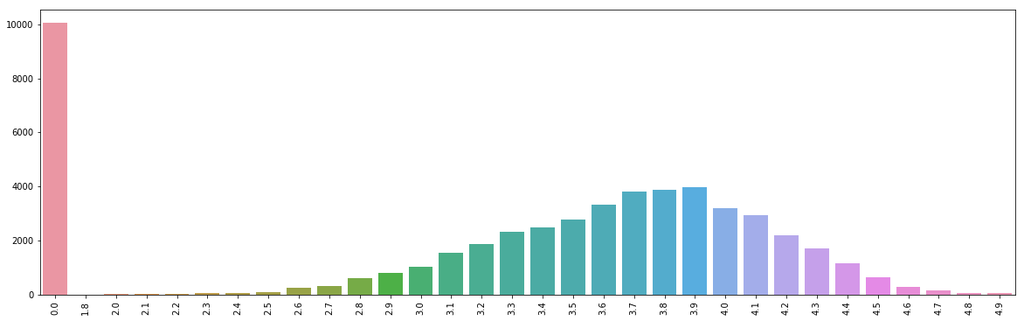

```python
rate_v = []
rate_c = []
for val, cnt in df['rate'].value_counts().iteritems():
    rate_v.append(val)
    rate_c.append(cnt)
plt.figure(figsize=(20, 6))
rate_val = seaborn.barplot(x = rate_v, y = rate_c)
plt.xticks(rotation='vertical')
```

For the rate, as you can see from the above graph, there are a very high number of restaurants which are new or have no rating and hence have been assigned 0. This lets us know about the popularity of those restaurants. It mostly means that it is not yet popular enough and hence most people don't go there. Also, majority of the restaurants have a rating between 3-4.5, and there are very few which ratings near 2 which means not a good restaurant. Similary there are very few with rating around 4.9 which means extraordinarily good. Thus, maximum restaurants fall within an average comparable range.

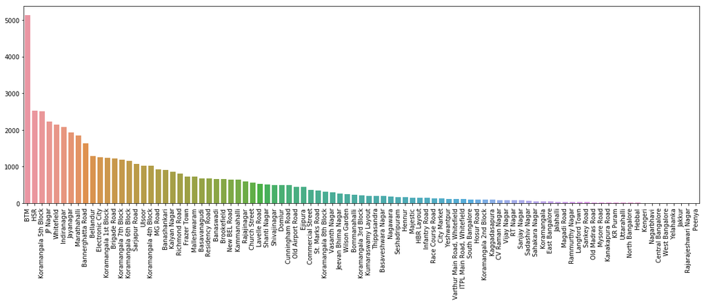

```python
plt.figure(figsize=(20, 6))
loc_v = []
loc_c = []
for val, cnt in df['location'].value_counts().iteritems():
    loc_v.append(val)
    loc_c.append(cnt)
loc_bar = seaborn.barplot(x=loc_v, y=loc_c)
plt.xticks(rotation='vertical')
```

This is a plot between location and the number of restaurants in that location. From this graph, we can see that BTM has the highest number of restaurants, and it also surpasses other locations with a very high margin. And, some of the locations contain maybe 1 or 2 restaurants, and hence are not famous.

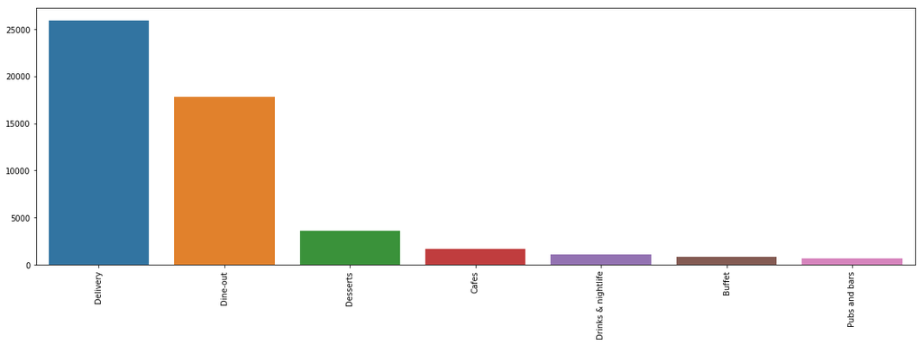

```python
plt.figure(figsize=(20, 6))
list_v = []
list_c = []
for val,cnt in df['listed_in(type)'].value_counts().iteritems():
    list_v.append(val)
    list_c.append(cnt)
loc_bar = seaborn.barplot(x=list_v, y=list_c)
plt.xticks(rotation='vertical')
```

This graph depicts the type of restaurants available. Majorly, there are 7 different types, but Deluvery and dine out are the most famous ones on zomato.

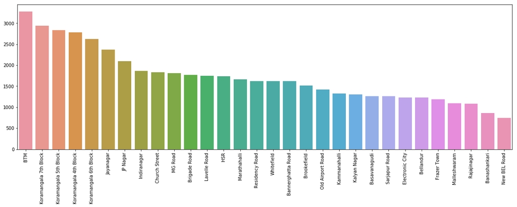

```python
plt.figure(figsize=(20, 6))
city_v = []
city_c = []
for val,cnt in df['listed_in(city)'].value_counts().iteritems():
    city_v.append(val)
    city_c.append(cnt)
loc_bar = seaborn.barplot(x=city_v, y=city_c)
plt.xticks(rotation='vertical')
```

This graph tells almost the same thing as location, but it groups many small neighborhoods into one and is hence a broader view of the location. But for our model, we need more details and hence would prefer the location column over this.

So, from these graphs ad unique values in the column, we can say that url, name, phone, reviews, menu_items, listed_in(city) are some of the columns which are not relevant to our model training.

```python
df['approx_cost(for two people)'] = df['approx_cost(for two people)'].str.replace(',', '').astype(float)
```

*c Detect duplicates and remove them*

According to the dataset, a duplicate row would be the one with the same name, address and location. Hence, duplicates are detected and dropped using drop_duplicates on the name, address and location column. A new dataframe is formed to retain the main dataframe for use if needed.

```python
df_unique=(df.drop_duplicates(subset=["name","address","location"],keep="first")).copy()
df_unique = df_unique[['location','rate','rest_type','cuisines','approx_cost(for two people)']]
```

*d Neighborhood with highest average rating*

The neighborhood with highest average rating is Rajarajeshwari Nagar with a rating of 3.85. The major characteristics of this rating are that is famously a Casual Dining restaurant, mostly famous for Chinese, Italian, Mexican and Thai food. Also, this area does have a lot of delivery options. The normal cost range in this area is around 700 Rs.

```python
#Multi Label Binarizer is used to one hot encode the rest_type and cuisine columns as it has a list of values
#in each row and thus need to be encoded to binary values for model to use.

from sklearn.preprocessing import MultiLabelBinarizer
mlb = MultiLabelBinarizer()
final_rest_type = []
df_unique['rest_type'] = df_unique['rest_type'].fillna('')
for i in df_unique['rest_type']:
    if ',' in i:
        t = i.split(",")
        temp = []
        for j in t:
            j = j.strip()
            temp.append(j)
        final_rest_type.append(temp)
    else:
        temp = []
        temp.append(i)
        final_rest_type.append(temp)

arr = mlb.fit_transform(final_rest_type)
df_rest_type = (pd.DataFrame(arr, index=df_unique.index, columns=mlb.classes_))
df_rest_type.shape
```

```
(12530, 26)
```

```python
mlb1 = MultiLabelBinarizer()
final_cuisine = []
df_unique['cuisines'] = df_unique['cuisines'].fillna('')
for i in df_unique['cuisines']:
    if ',' in i:
        t = i.split(",")
        temp = []
        for j in t:
            j = j.strip()
            temp.append(j)
        final_cuisine.append(temp)
    else:
        temp = []
        temp.append(i)
        final_cuisine.append(temp)

arr1 = mlb1.fit_transform(final_cuisine)
df_cuisine = (pd.DataFrame(arr1, index=df_unique.index, columns=mlb1.classes_))
df_cuisine.shape
```

```
(12530, 108)
```

```python
df_unique = pd.concat([df_unique, df_rest_type, df_cuisine], join = 'inner', axis = 1, sort=False)
```

```python
df_unique.drop(['','rest_type','cuisines'], 1, inplace=True)
```

```python
df_loc = df_unique.groupby('location').mean()
```

```python
df_loc = df_loc.sort_values('rate', ascending =False)
df_loc
```

| location | rate | approx_cost(for two people) | Bakery | Bar | Beverage Shop | Bhojanalya | Cafe | Casual Dining | Club | Confectionery | ... | Sushi | Tamil | Tea | Tex-Mex | Thai | Tibetan | Turkish | Vegan | Vietnamese | Wraps |
| --- | --- | --- | --- | --- | --- | --- | --- | --- | --- | --- | --- | --- | --- | --- | --- | --- | --- | --- | --- | --- | --- |
| Rajarajeshwari Nagar | 3.850000 | 725.000000 | 0.000000 | 0.000000 | 0.000000 | 0.0 | 0.000000 | 0.500000 | 0.000000 | 0.000000 | ... | 0.000000 | 0.000000 | 0.000000 | 0.000000 | 0.500000 | 0.000000 | 0.000000 | 0.000000 | 0.000000 | 0.000000 |
| St. Marks Road | 3.817143 | 754.285714 | 0.000000 | 0.200000 | 0.000000 | 0.0 | 0.057143 | 0.514286 | 0.000000 | 0.000000 | ... | 0.000000 | 0.000000 | 0.028571 | 0.000000 | 0.000000 | 0.000000 | 0.028571 | 0.000000 | 0.000000 | 0.000000 |
| Lavelle Road | 3.782143 | 1323.214286 | 0.107143 | 0.178571 | 0.035714 | 0.0 | 0.107143 | 0.375000 | 0.000000 | 0.017857 | ... | 0.000000 | 0.000000 | 0.000000 | 0.017857 | 0.071429 | 0.000000 | 0.000000 | 0.000000 | 0.000000 | 0.000000 |
| Race Course Road | 3.733333 | 1316.666667 | 0.000000 | 0.200000 | 0.033333 | 0.0 | 0.066667 | 0.566667 | 0.000000 | 0.000000 | ... | 0.000000 | 0.000000 | 0.033333 | 0.000000 | 0.066667 | 0.000000 | 0.000000 | 0.000000 | 0.033333 | 0.000000 |
| Sankey Road | 3.730769 | 2526.923077 | 0.000000 | 0.076923 | 0.000000 | 0.0 | 0.000000 | 0.076923 | 0.076923 | 0.000000 | ... | 0.000000 | 0.000000 | 0.000000 | 0.000000 | 0.000000 | 0.000000 | 0.000000 | 0.000000 | 0.000000 | 0.000000 |
| Kengeri | 3.700000 | 500.000000 | 0.000000 | 0.000000 | 0.000000 | 0.0 | 1.000000 | 0.000000 | 0.000000 | 0.000000 | ... | 0.000000 | 0.000000 | 0.000000 | 0.000000 | 0.000000 | 0.000000 | 0.000000 | 0.000000 | 0.000000 | 0.000000 |
| Church Street | 3.692982 | 762.280702 | 0.000000 | 0.105263 | 0.052632 | 0.0 | 0.192982 | 0.421053 | 0.000000 | 0.000000 | ... | 0.000000 | 0.000000 | 0.017544 | 0.000000 | 0.000000 | 0.000000 | 0.000000 | 0.000000 | 0.000000 | 0.000000 |
| Central Bangalore | 3.650000 | 400.000000 | 0.000000 | 0.000000 | 0.000000 | 0.0 | 0.000000 | 0.000000 | 0.000000 | 0.000000 | ... | 0.000000 | 0.000000 | 0.000000 | 0.000000 | 0.000000 | 0.000000 | 0.000000 | 0.000000 | 0.000000 | 0.000000 |
| Langford Town | 3.650000 | 675.000000 | 0.000000 | 0.500000 | 0.000000 | 0.0 | 0.000000 | 0.500000 | 0.000000 | 0.000000 | ... | 0.000000 | 0.000000 | 0.000000 | 0.000000 | 0.000000 | 0.000000 | 0.000000 | 0.000000 | 0.000000 | 0.000000 |
| Cunningham Road | 3.583673 | 722.448980 | 0.040816 | 0.020408 | 0.061224 | 0.0 | 0.122449 | 0.408163 | 0.000000 | 0.000000 | ... | 0.000000 | 0.000000 | 0.040816 | 0.000000 | 0.061224 | 0.000000 | 0.000000 | 0.000000 | 0.000000 | 0.000000 |
| Koramangala 5th Block | 3.501115 | 577.443609 | 0.014870 | 0.037175 | 0.059480 | 0.0 | 0.126394 | 0.275093 | 0.000000 | 0.000000 | ... | 0.003717 | 0.000000 | 0.014870 | 0.000000 | 0.040892 | 0.033457 | 0.011152 | 0.000000 | 0.011152 | 0.000000 |
| Kanakapura Road | 3.470000 | 590.000000 | 0.000000 | 0.100000 | 0.000000 | 0.0 | 0.000000 | 0.700000 | 0.000000 | 0.000000 | ... | 0.000000 | 0.000000 | 0.000000 | 0.000000 | 0.000000 | 0.000000 | 0.000000 | 0.000000 | 0.000000 | 0.000000 |
| Residency Road | 3.373810 | 933.928571 | 0.000000 | 0.083333 | 0.011905 | 0.0 | 0.083333 | 0.297619 | 0.000000 | 0.011905 | ... | 0.000000 | 0.000000 | 0.011905 | 0.000000 | 0.023810 | 0.000000 | 0.000000 | 0.000000 | 0.011905 | 0.000000 |
| Old Madras Road | 3.355556 | 455.555556 | 0.000000 | 0.000000 | 0.000000 | 0.0 | 0.111111 | 0.111111 | 0.000000 | 0.000000 | ... | 0.000000 | 0.000000 | 0.000000 | 0.000000 | 0.000000 | 0.111111 | 0.000000 | 0.000000 | 0.000000 | 0.000000 |
| Koramangala 7th Block | 3.343836 | 523.448276 | 0.047945 | 0.047945 | 0.047945 | 0.0 | 0.095890 | 0.253425 | 0.000000 | 0.000000 | ... | 0.000000 | 0.000000 | 0.027397 | 0.000000 | 0.013699 | 0.020548 | 0.000000 | 0.000000 | 0.000000 | 0.000000 |
| Sadashiv Nagar | 3.315625 | 668.750000 | 0.062500 | 0.000000 | 0.031250 | 0.0 | 0.187500 | 0.406250 | 0.031250 | 0.000000 | ... | 0.000000 | 0.000000 | 0.000000 | 0.000000 | 0.031250 | 0.000000 | 0.000000 | 0.000000 | 0.031250 | 0.000000 |
| MG Road | 3.304082 | 1056.122449 | 0.040816 | 0.051020 | 0.020408 | 0.0 | 0.173469 | 0.275510 | 0.010204 | 0.010204 | ... | 0.000000 | 0.000000 | 0.020408 | 0.010204 | 0.061224 | 0.010204 | 0.000000 | 0.000000 | 0.000000 | 0.000000 |
| Koramangala 6th Block | 3.283444 | 548.666667 | 0.013245 | 0.039735 | 0.033113 | 0.0 | 0.072848 | 0.198675 | 0.000000 | 0.000000 | ... | 0.000000 | 0.000000 | 0.019868 | 0.000000 | 0.019868 | 0.000000 | 0.000000 | 0.000000 | 0.000000 | 0.000000 |
| Jeevan Bhima Nagar | 3.282051 | 389.230769 | 0.051282 | 0.000000 | 0.038462 | 0.0 | 0.038462 | 0.243590 | 0.000000 | 0.000000 | ... | 0.000000 | 0.000000 | 0.012821 | 0.000000 | 0.025641 | 0.000000 | 0.012821 | 0.000000 | 0.000000 | 0.000000 |
| Infantry Road | 3.253333 | 966.666667 | 0.000000 | 0.200000 | 0.066667 | 0.0 | 0.133333 | 0.666667 | 0.000000 | 0.000000 | ... | 0.000000 | 0.000000 | 0.000000 | 0.000000 | 0.133333 | 0.000000 | 0.000000 | 0.000000 | 0.066667 | 0.000000 |
| Koramangala 3rd Block | 3.243478 | 660.869565 | 0.043478 | 0.043478 | 0.000000 | 0.0 | 0.260870 | 0.130435 | 0.000000 | 0.000000 | ... | 0.000000 | 0.000000 | 0.000000 | 0.000000 | 0.043478 | 0.000000 | 0.000000 | 0.000000 | 0.000000 | 0.000000 |
| Sahakara Nagar | 3.240000 | 446.666667 | 0.000000 | 0.022222 | 0.111111 | 0.0 | 0.044444 | 0.133333 | 0.000000 | 0.000000 | ... | 0.000000 | 0.000000 | 0.022222 | 0.000000 | 0.022222 | 0.000000 | 0.000000 | 0.000000 | 0.000000 | 0.000000 |
| Yeshwantpur | 3.237681 | 418.840580 | 0.043478 | 0.043478 | 0.014493 | 0.0 | 0.028986 | 0.202899 | 0.000000 | 0.000000 | ... | 0.000000 | 0.000000 | 0.000000 | 0.000000 | 0.014493 | 0.000000 | 0.000000 | 0.000000 | 0.000000 | 0.000000 |
| Peenya | 3.200000 | 300.000000 | 0.000000 | 0.000000 | 0.000000 | 0.0 | 0.000000 | 0.000000 | 0.000000 | 0.000000 | ... | 0.000000 | 0.000000 | 0.000000 | 0.000000 | 0.000000 | 0.000000 | 0.000000 | 0.000000 | 0.000000 | 0.000000 |
| Malleshwaram | 3.163445 | 484.117647 | 0.050420 | 0.021008 | 0.042017 | 0.0 | 0.075630 | 0.168067 | 0.000000 | 0.008403 | ... | 0.000000 | 0.000000 | 0.004202 | 0.004202 | 0.016807 | 0.004202 | 0.000000 | 0.000000 | 0.004202 | 0.004202 |
| Jayanagar | 3.135695 | 444.277929 | 0.054496 | 0.010899 | 0.043597 | 0.0 | 0.095368 | 0.242507 | 0.000000 | 0.000000 | ... | 0.000000 | 0.000000 | 0.013624 | 0.000000 | 0.016349 | 0.002725 | 0.005450 | 0.000000 | 0.002725 | 0.002725 |
| Vijay Nagar | 3.113793 | 361.929825 | 0.017241 | 0.017241 | 0.086207 | 0.0 | 0.034483 | 0.137931 | 0.000000 | 0.000000 | ... | 0.000000 | 0.000000 | 0.000000 | 0.000000 | 0.000000 | 0.000000 | 0.000000 | 0.000000 | 0.000000 | 0.000000 |
| Indiranagar | 3.086492 | 600.207940 | 0.031895 | 0.052533 | 0.031895 | 0.0 | 0.112570 | 0.296435 | 0.000000 | 0.000000 | ... | 0.003752 | 0.000000 | 0.011257 | 0.003752 | 0.028143 | 0.001876 | 0.001876 | 0.000000 | 0.009381 | 0.000000 |
| Basavanagudi | 3.082938 | 339.620853 | 0.066351 | 0.018957 | 0.018957 | 0.0 | 0.042654 | 0.156398 | 0.000000 | 0.000000 | ... | 0.000000 | 0.000000 | 0.000000 | 0.000000 | 0.004739 | 0.000000 | 0.000000 | 0.000000 | 0.000000 | 0.000000 |
| Brigade Road | 3.030534 | 594.122137 | 0.038168 | 0.045802 | 0.038168 | 0.0 | 0.083969 | 0.305344 | 0.007634 | 0.000000 | ... | 0.007634 | 0.000000 | 0.007634 | 0.000000 | 0.015267 | 0.038168 | 0.000000 | 0.000000 | 0.000000 | 0.000000 |
| ... | ... | ... | ... | ... | ... | ... | ... | ... | ... | ... | ... | ... | ... | ... | ... | ... | ... | ... | ... | ... | ... |
| Whitefield | 2.507441 | 558.038549 | 0.032694 | 0.021421 | 0.025930 | 0.0 | 0.040586 | 0.220970 | 0.000000 | 0.003382 | ... | 0.002255 | 0.000000 | 0.005637 | 0.001127 | 0.010147 | 0.003382 | 0.000000 | 0.000000 | 0.002255 | 0.000000 |
| Bellandur | 2.500826 | 481.763085 | 0.052342 | 0.016529 | 0.030303 | 0.0 | 0.044077 | 0.231405 | 0.002755 | 0.000000 | ... | 0.000000 | 0.002755 | 0.013774 | 0.005510 | 0.011019 | 0.000000 | 0.002755 | 0.000000 | 0.000000 | 0.000000 |
| Hennur | 2.500000 | 388.281250 | 0.076923 | 0.015385 | 0.046154 | 0.0 | 0.061538 | 0.092308 | 0.000000 | 0.000000 | ... | 0.000000 | 0.000000 | 0.000000 | 0.000000 | 0.000000 | 0.000000 | 0.000000 | 0.000000 | 0.000000 | 0.000000 |
| Koramangala 1st Block | 2.440361 | 411.144578 | 0.042169 | 0.036145 | 0.012048 | 0.0 | 0.042169 | 0.102410 | 0.000000 | 0.000000 | ... | 0.000000 | 0.000000 | 0.012048 | 0.000000 | 0.018072 | 0.000000 | 0.000000 | 0.000000 | 0.000000 | 0.006024 |
| Banaswadi | 2.429187 | 378.921569 | 0.038278 | 0.019139 | 0.028708 | 0.0 | 0.052632 | 0.186603 | 0.000000 | 0.004785 | ... | 0.000000 | 0.000000 | 0.000000 | 0.000000 | 0.019139 | 0.009569 | 0.000000 | 0.000000 | 0.004785 | 0.000000 |
| Thippasandra | 2.423288 | 340.958904 | 0.013699 | 0.013699 | 0.027397 | 0.0 | 0.027397 | 0.109589 | 0.000000 | 0.000000 | ... | 0.000000 | 0.000000 | 0.000000 | 0.000000 | 0.013699 | 0.000000 | 0.000000 | 0.000000 | 0.000000 | 0.000000 |
| East Bangalore | 2.417391 | 391.304348 | 0.043478 | 0.000000 | 0.000000 | 0.0 | 0.000000 | 0.000000 | 0.000000 | 0.000000 | ... | 0.000000 | 0.000000 | 0.000000 | 0.000000 | 0.043478 | 0.000000 | 0.000000 | 0.000000 | 0.000000 | 0.000000 |
| Magadi Road | 2.378261 | 341.304348 | 0.086957 | 0.000000 | 0.000000 | 0.0 | 0.000000 | 0.130435 | 0.000000 | 0.000000 | ... | 0.000000 | 0.000000 | 0.000000 | 0.000000 | 0.000000 | 0.000000 | 0.000000 | 0.000000 | 0.000000 | 0.000000 |
| Jalahalli | 2.372727 | 363.636364 | 0.090909 | 0.000000 | 0.000000 | 0.0 | 0.000000 | 0.227273 | 0.000000 | 0.000000 | ... | 0.000000 | 0.000000 | 0.000000 | 0.000000 | 0.000000 | 0.045455 | 0.000000 | 0.000000 | 0.000000 | 0.000000 |
| South Bangalore | 2.353571 | 345.714286 | 0.000000 | 0.000000 | 0.000000 | 0.0 | 0.000000 | 0.000000 | 0.000000 | 0.000000 | ... | 0.000000 | 0.000000 | 0.000000 | 0.000000 | 0.071429 | 0.000000 | 0.000000 | 0.000000 | 0.000000 | 0.000000 |
| Varthur Main Road, Whitefield | 2.353333 | 355.555556 | 0.022222 | 0.022222 | 0.022222 | 0.0 | 0.000000 | 0.066667 | 0.000000 | 0.000000 | ... | 0.000000 | 0.000000 | 0.000000 | 0.000000 | 0.044444 | 0.000000 | 0.000000 | 0.000000 | 0.000000 | 0.000000 |
| CV Raman Nagar | 2.306818 | 336.363636 | 0.000000 | 0.000000 | 0.068182 | 0.0 | 0.022727 | 0.090909 | 0.000000 | 0.000000 | ... | 0.000000 | 0.000000 | 0.000000 | 0.000000 | 0.022727 | 0.000000 | 0.000000 | 0.000000 | 0.000000 | 0.000000 |
| Basaveshwara Nagar | 2.294286 | 397.572816 | 0.038095 | 0.019048 | 0.038095 | 0.0 | 0.047619 | 0.190476 | 0.000000 | 0.000000 | ... | 0.000000 | 0.000000 | 0.000000 | 0.000000 | 0.000000 | 0.000000 | 0.000000 | 0.000000 | 0.000000 | 0.000000 |
| Shanti Nagar | 2.281818 | 409.090909 | 0.064935 | 0.012987 | 0.051948 | 0.0 | 0.064935 | 0.246753 | 0.000000 | 0.000000 | ... | 0.000000 | 0.000000 | 0.012987 | 0.000000 | 0.000000 | 0.012987 | 0.000000 | 0.000000 | 0.000000 | 0.000000 |
| Mysore Road | 2.238462 | 396.153846 | 0.000000 | 0.076923 | 0.000000 | 0.0 | 0.000000 | 0.384615 | 0.000000 | 0.000000 | ... | 0.000000 | 0.000000 | 0.000000 | 0.000000 | 0.000000 | 0.000000 | 0.000000 | 0.000000 | 0.000000 | 0.000000 |
| Koramangala | 2.230000 | 410.000000 | 0.000000 | 0.000000 | 0.000000 | 0.0 | 0.000000 | 0.000000 | 0.000000 | 0.000000 | ... | 0.000000 | 0.000000 | 0.000000 | 0.000000 | 0.000000 | 0.000000 | 0.000000 | 0.000000 | 0.000000 | 0.000000 |
| Wilson Garden | 2.210000 | 368.000000 | 0.060000 | 0.020000 | 0.000000 | 0.0 | 0.040000 | 0.120000 | 0.000000 | 0.000000 | ... | 0.000000 | 0.000000 | 0.000000 | 0.000000 | 0.000000 | 0.000000 | 0.000000 | 0.000000 | 0.000000 | 0.000000 |
| Sanjay Nagar | 2.197872 | 368.085106 | 0.042553 | 0.021277 | 0.021277 | 0.0 | 0.000000 | 0.063830 | 0.000000 | 0.000000 | ... | 0.000000 | 0.000000 | 0.021277 | 0.000000 | 0.021277 | 0.000000 | 0.000000 | 0.000000 | 0.000000 | 0.000000 |
| KR Puram | 2.184615 | 346.153846 | 0.000000 | 0.000000 | 0.000000 | 0.0 | 0.000000 | 0.153846 | 0.000000 | 0.000000 | ... | 0.000000 | 0.000000 | 0.000000 | 0.000000 | 0.076923 | 0.000000 | 0.000000 | 0.000000 | 0.000000 | 0.000000 |
| Electronic City | 2.178493 | 461.714678 | 0.036986 | 0.023288 | 0.023288 | 0.0 | 0.027397 | 0.217808 | 0.000000 | 0.000000 | ... | 0.000000 | 0.001370 | 0.004110 | 0.000000 | 0.013699 | 0.002740 | 0.000000 | 0.000000 | 0.001370 | 0.000000 |
| HBR Layout | 2.035556 | 380.000000 | 0.088889 | 0.000000 | 0.044444 | 0.0 | 0.066667 | 0.177778 | 0.000000 | 0.000000 | ... | 0.000000 | 0.000000 | 0.022222 | 0.000000 | 0.000000 | 0.000000 | 0.000000 | 0.022222 | 0.000000 | 0.022222 |
| North Bangalore | 1.928571 | 314.285714 | 0.000000 | 0.000000 | 0.000000 | 0.0 | 0.000000 | 0.000000 | 0.000000 | 0.000000 | ... | 0.000000 | 0.000000 | 0.000000 | 0.000000 | 0.000000 | 0.000000 | 0.000000 | 0.000000 | 0.000000 | 0.000000 |
| Shivajinagar | 1.877049 | 298.360656 | 0.032787 | 0.032787 | 0.032787 | 0.0 | 0.081967 | 0.114754 | 0.000000 | 0.000000 | ... | 0.000000 | 0.000000 | 0.000000 | 0.000000 | 0.000000 | 0.000000 | 0.000000 | 0.000000 | 0.000000 | 0.000000 |
| Ejipura | 1.816923 | 305.384615 | 0.000000 | 0.000000 | 0.046154 | 0.0 | 0.000000 | 0.061538 | 0.000000 | 0.000000 | ... | 0.000000 | 0.000000 | 0.000000 | 0.000000 | 0.000000 | 0.000000 | 0.000000 | 0.000000 | 0.000000 | 0.000000 |
| Hebbal | 1.800000 | 487.500000 | 0.125000 | 0.125000 | 0.000000 | 0.0 | 0.000000 | 0.250000 | 0.000000 | 0.000000 | ... | 0.000000 | 0.000000 | 0.000000 | 0.000000 | 0.000000 | 0.000000 | 0.000000 | 0.000000 | 0.000000 | 0.000000 |
| Bommanahalli | 1.751485 | 399.690000 | 0.039604 | 0.009901 | 0.039604 | 0.0 | 0.009901 | 0.138614 | 0.000000 | 0.000000 | ... | 0.000000 | 0.000000 | 0.000000 | 0.000000 | 0.000000 | 0.000000 | 0.000000 | 0.000000 | 0.000000 | 0.000000 |
| West Bangalore | 1.700000 | 362.500000 | 0.000000 | 0.000000 | 0.000000 | 0.0 | 0.000000 | 0.000000 | 0.000000 | 0.000000 | ... | 0.000000 | 0.000000 | 0.000000 | 0.000000 | 0.000000 | 0.000000 | 0.000000 | 0.000000 | 0.000000 | 0.000000 |
| City Market | 1.657778 | 299.977778 | 0.022222 | 0.000000 | 0.022222 | 0.0 | 0.022222 | 0.200000 | 0.000000 | 0.000000 | ... | 0.000000 | 0.000000 | 0.000000 | 0.000000 | 0.000000 | 0.000000 | 0.000000 | 0.000000 | 0.000000 | 0.000000 |
| Nagarbhavi | 0.850000 | 437.500000 | 0.000000 | 0.000000 | 0.000000 | 0.0 | 0.000000 | 0.500000 | 0.000000 | 0.000000 | ... | 0.000000 | 0.000000 | 0.000000 | 0.000000 | 0.000000 | 0.000000 | 0.000000 | 0.000000 | 0.000000 | 0.000000 |
| Jakkur | 0.000000 | 400.000000 | 0.000000 | 0.000000 | 0.000000 | 0.0 | 0.000000 | 0.000000 | 0.000000 | 0.000000 | ... | 0.000000 | 0.000000 | 0.000000 | 0.000000 | 0.000000 | 0.000000 | 0.000000 | 0.000000 | 0.000000 | 0.000000 |

93 rows × 134 columns

```python
out = df_loc.iloc[0]
for i,v in out.items():
    if v>0.0:
        print (i,v)
```

```
rate 3.85
approx_cost(for two people) 725.0
Casual Dining 0.5
Delivery 0.5
Chinese 0.5
Italian 0.5
Mexican 0.5
Thai 0.5
```

**Question 3**

*a Task being solved* The task being solved is supervised regression learning.

It is supervised because we have the labelled training set. And, since the output column is continuous values, the task is regression.

*b Models to choose* The models which can be chosen are Decision Tree Regressor, Random Forest Regressor, XGBoost. These three models are the three moels with three different characteristics. Hence, using these models will help us in understanding the difference between the three. Decision tree is a simple tree model. Random Forest is an ensemble model which is made up of multiple different trees. Hence it is an advanced version of decision tree. XGBoost is also an ensemble model, but it is also based on the concept of gradient boosting. Gradient boosting helps in resolving the errors made in the previous step and thus improving the model. Thus the choice of these three different algorithms.

*c Metrics used to evaluate the model* The metrics which will be used to evaluate the model will be r2_score. R^2 (coefficient of determination) score is the regression score function.

*d How do you make sure not to overfit?* To make sure the model does not overfit, we need to use cross-validation so that the training and test samples get rotated and the model is thus trained on all different types of data. To view this, a learning curve is plotted on the training and test dataset, which will give us the visualization of how the model performs on the training set and the testing set.

```python
df_temp = pd.get_dummies(df_unique['location'], prefix = 'loc', drop_first=True)
```

```python
df_unique = pd.concat([df_unique,df_temp], axis=1)
```

```python
df_unique.fillna('')
```

|  | location | rate | approx_cost(for two people) | Bakery | Bar | Beverage Shop | Bhojanalya | Cafe | Casual Dining | Club | ... | loc_Ulsoor | loc_Uttarahalli | loc_Varthur Main Road, Whitefield | loc_Vasanth Nagar | loc_Vijay Nagar | loc_West Bangalore | loc_Whitefield | loc_Wilson Garden | loc_Yelahanka | loc_Yeshwantpur |
| --- | --- | --- | --- | --- | --- | --- | --- | --- | --- | --- | --- | --- | --- | --- | --- | --- | --- | --- | --- | --- | --- |
| 0 | Banashankari | 4.1 | 800 | 0 | 0 | 0 | 0 | 0 | 1 | 0 | ... | 0 | 0 | 0 | 0 | 0 | 0 | 0 | 0 | 0 | 0 |
| 1 | Banashankari | 4.1 | 800 | 0 | 0 | 0 | 0 | 0 | 1 | 0 | ... | 0 | 0 | 0 | 0 | 0 | 0 | 0 | 0 | 0 | 0 |
| 2 | Banashankari | 3.8 | 800 | 0 | 0 | 0 | 0 | 1 | 1 | 0 | ... | 0 | 0 | 0 | 0 | 0 | 0 | 0 | 0 | 0 | 0 |
| 3 | Banashankari | 3.7 | 300 | 0 | 0 | 0 | 0 | 0 | 0 | 0 | ... | 0 | 0 | 0 | 0 | 0 | 0 | 0 | 0 | 0 | 0 |
| 4 | Basavanagudi | 3.8 | 600 | 0 | 0 | 0 | 0 | 0 | 1 | 0 | ... | 0 | 0 | 0 | 0 | 0 | 0 | 0 | 0 | 0 | 0 |
| 5 | Basavanagudi | 3.8 | 600 | 0 | 0 | 0 | 0 | 0 | 1 | 0 | ... | 0 | 0 | 0 | 0 | 0 | 0 | 0 | 0 | 0 | 0 |
| 6 | Mysore Road | 3.6 | 800 | 0 | 0 | 0 | 0 | 0 | 1 | 0 | ... | 0 | 0 | 0 | 0 | 0 | 0 | 0 | 0 | 0 | 0 |
| 7 | Banashankari | 4.6 | 600 | 0 | 0 | 0 | 0 | 1 | 1 | 0 | ... | 0 | 0 | 0 | 0 | 0 | 0 | 0 | 0 | 0 | 0 |
| 8 | Banashankari | 4.0 | 700 | 0 | 0 | 0 | 0 | 1 | 0 | 0 | ... | 0 | 0 | 0 | 0 | 0 | 0 | 0 | 0 | 0 | 0 |
| 9 | Banashankari | 4.2 | 550 | 0 | 0 | 0 | 0 | 1 | 0 | 0 | ... | 0 | 0 | 0 | 0 | 0 | 0 | 0 | 0 | 0 | 0 |
| 10 | Banashankari | 4.1 | 500 | 0 | 0 | 0 | 0 | 1 | 0 | 0 | ... | 0 | 0 | 0 | 0 | 0 | 0 | 0 | 0 | 0 | 0 |
| 11 | Banashankari | 4.2 | 600 | 0 | 0 | 0 | 0 | 1 | 0 | 0 | ... | 0 | 0 | 0 | 0 | 0 | 0 | 0 | 0 | 0 | 0 |
| 12 | Banashankari | 4.2 | 500 | 0 | 0 | 0 | 0 | 1 | 0 | 0 | ... | 0 | 0 | 0 | 0 | 0 | 0 | 0 | 0 | 0 | 0 |
| 13 | Banashankari | 4.0 | 450 | 0 | 0 | 0 | 0 | 1 | 0 | 0 | ... | 0 | 0 | 0 | 0 | 0 | 0 | 0 | 0 | 0 | 0 |
| 15 | Banashankari | 3.8 | 650 | 0 | 0 | 0 | 0 | 1 | 0 | 0 | ... | 0 | 0 | 0 | 0 | 0 | 0 | 0 | 0 | 0 | 0 |
| 16 | Banashankari | 3.9 | 800 | 0 | 0 | 0 | 0 | 1 | 0 | 0 | ... | 0 | 0 | 0 | 0 | 0 | 0 | 0 | 0 | 0 | 0 |
| 17 | Banashankari | 3.8 | 700 | 0 | 0 | 0 | 0 | 1 | 0 | 0 | ... | 0 | 0 | 0 | 0 | 0 | 0 | 0 | 0 | 0 | 0 |
| 18 | Banashankari | 3.9 | 300 | 0 | 0 | 0 | 0 | 1 | 0 | 0 | ... | 0 | 0 | 0 | 0 | 0 | 0 | 0 | 0 | 0 | 0 |
| 19 | Banashankari | 3.1 | 400 | 0 | 0 | 0 | 0 | 1 | 0 | 0 | ... | 0 | 0 | 0 | 0 | 0 | 0 | 0 | 0 | 0 | 0 |
| 20 | Banashankari | 3.0 | 400 | 0 | 0 | 0 | 0 | 1 | 0 | 0 | ... | 0 | 0 | 0 | 0 | 0 | 0 | 0 | 0 | 0 | 0 |
| 21 | Banashankari | 3.7 | 500 | 0 | 0 | 0 | 0 | 1 | 0 | 0 | ... | 0 | 0 | 0 | 0 | 0 | 0 | 0 | 0 | 0 | 0 |
| 22 | Banashankari | 3.6 | 900 | 0 | 0 | 0 | 0 | 1 | 0 | 0 | ... | 0 | 0 | 0 | 0 | 0 | 0 | 0 | 0 | 0 | 0 |
| 23 | Banashankari | 3.6 | 600 | 0 | 0 | 0 | 0 | 1 | 0 | 0 | ... | 0 | 0 | 0 | 0 | 0 | 0 | 0 | 0 | 0 | 0 |
| 24 | Banashankari | 3.7 | 300 | 0 | 0 | 0 | 0 | 1 | 0 | 0 | ... | 0 | 0 | 0 | 0 | 0 | 0 | 0 | 0 | 0 | 0 |
| 25 | Banashankari | 3.2 | 600 | 0 | 0 | 0 | 0 | 1 | 0 | 0 | ... | 0 | 0 | 0 | 0 | 0 | 0 | 0 | 0 | 0 | 0 |
| 26 | Banashankari | 3.8 | 200 | 0 | 0 | 0 | 0 | 1 | 0 | 0 | ... | 0 | 0 | 0 | 0 | 0 | 0 | 0 | 0 | 0 | 0 |
| 27 | Banashankari | 3.3 | 500 | 0 | 0 | 0 | 0 | 1 | 0 | 0 | ... | 0 | 0 | 0 | 0 | 0 | 0 | 0 | 0 | 0 | 0 |
| 28 | Banashankari | 3.3 | 550 | 0 | 0 | 0 | 0 | 1 | 0 | 0 | ... | 0 | 0 | 0 | 0 | 0 | 0 | 0 | 0 | 0 | 0 |
| 29 | Basavanagudi | 3.8 | 550 | 0 | 0 | 0 | 0 | 1 | 1 | 0 | ... | 0 | 0 | 0 | 0 | 0 | 0 | 0 | 0 | 0 | 0 |
| 30 | Basavanagudi | 4.0 | 600 | 0 | 0 | 0 | 0 | 1 | 0 | 0 | ... | 0 | 0 | 0 | 0 | 0 | 0 | 0 | 0 | 0 | 0 |
| ... | ... | ... | ... | ... | ... | ... | ... | ... | ... | ... | ... | ... | ... | ... | ... | ... | ... | ... | ... | ... | ... |
| 51540 | Whitefield | 2.9 | 300 | 0 | 0 | 0 | 0 | 0 | 0 | 0 | ... | 0 | 0 | 0 | 0 | 0 | 0 | 1 | 0 | 0 | 0 |
| 51542 | Whitefield | 0.0 | 250 | 0 | 0 | 0 | 0 | 0 | 0 | 0 | ... | 0 | 0 | 0 | 0 | 0 | 0 | 1 | 0 | 0 | 0 |
| 51552 | Whitefield | 3.5 | 150 | 0 | 0 | 0 | 0 | 0 | 0 | 0 | ... | 0 | 0 | 0 | 0 | 0 | 0 | 1 | 0 | 0 | 0 |
| 51555 | Whitefield | 3.5 | 250 | 0 | 0 | 0 | 0 | 0 | 0 | 0 | ... | 0 | 0 | 0 | 0 | 0 | 0 | 1 | 0 | 0 | 0 |
| 51556 | Whitefield | 3.3 | 400 | 0 | 0 | 0 | 0 | 0 | 0 | 0 | ... | 0 | 0 | 0 | 0 | 0 | 0 | 1 | 0 | 0 | 0 |
| 51563 | Whitefield | 0.0 | 200 | 0 | 0 | 0 | 0 | 0 | 0 | 0 | ... | 0 | 0 | 0 | 0 | 0 | 0 | 1 | 0 | 0 | 0 |
| 51566 | Whitefield | 0.0 | 250 | 0 | 0 | 0 | 0 | 0 | 0 | 0 | ... | 0 | 0 | 0 | 0 | 0 | 0 | 1 | 0 | 0 | 0 |
| 51567 | Whitefield | 0.0 | 150 | 0 | 0 | 0 | 0 | 0 | 0 | 0 | ... | 0 | 0 | 0 | 0 | 0 | 0 | 1 | 0 | 0 | 0 |
| 51568 | Whitefield | 0.0 | 150 | 0 | 0 | 0 | 0 | 0 | 0 | 0 | ... | 0 | 0 | 0 | 0 | 0 | 0 | 1 | 0 | 0 | 0 |
| 51569 | Whitefield | 3.3 | 200 | 0 | 0 | 0 | 0 | 0 | 0 | 0 | ... | 0 | 0 | 0 | 0 | 0 | 0 | 1 | 0 | 0 | 0 |
| 51571 | Whitefield | 0.0 | 100 | 0 | 0 | 0 | 0 | 0 | 0 | 0 | ... | 0 | 0 | 0 | 0 | 0 | 0 | 1 | 0 | 0 | 0 |
| 51572 | Whitefield | 3.3 | 300 | 0 | 0 | 0 | 0 | 0 | 0 | 0 | ... | 0 | 0 | 0 | 0 | 0 | 0 | 1 | 0 | 0 | 0 |
| 51573 | Whitefield | 0.0 | 300 | 0 | 0 | 0 | 0 | 0 | 0 | 0 | ... | 0 | 0 | 0 | 0 | 0 | 0 | 1 | 0 | 0 | 0 |
| 51577 | Whitefield | 3.3 | 400 | 0 | 0 | 0 | 0 | 0 | 0 | 0 | ... | 0 | 0 | 0 | 0 | 0 | 0 | 1 | 0 | 0 | 0 |
| 51578 | Whitefield | 0.0 | 500 | 0 | 0 | 0 | 0 | 0 | 0 | 0 | ... | 0 | 0 | 0 | 0 | 0 | 0 | 1 | 0 | 0 | 0 |
| 51579 | Whitefield | 0.0 | 600 | 0 | 0 | 0 | 0 | 0 | 0 | 0 | ... | 0 | 0 | 0 | 0 | 0 | 0 | 1 | 0 | 0 | 0 |
| 51584 | Whitefield | 3.1 | 150 | 0 | 0 | 0 | 0 | 0 | 0 | 0 | ... | 0 | 0 | 0 | 0 | 0 | 0 | 1 | 0 | 0 | 0 |
| 51587 | Whitefield | 0.0 | 300 | 0 | 0 | 0 | 0 | 0 | 0 | 0 | ... | 0 | 0 | 0 | 0 | 0 | 0 | 1 | 0 | 0 | 0 |
| 51595 | Whitefield | 3.2 | 200 | 0 | 0 | 0 | 0 | 0 | 0 | 0 | ... | 0 | 0 | 0 | 0 | 0 | 0 | 1 | 0 | 0 | 0 |
| 51606 | ITPL Main Road, Whitefield | 4.6 | 1500 | 0 | 0 | 0 | 0 | 0 | 1 | 0 | ... | 0 | 0 | 0 | 0 | 0 | 0 | 0 | 0 | 0 | 0 |
| 51607 | ITPL Main Road, Whitefield | 4.3 | 2500 | 0 | 1 | 0 | 0 | 0 | 0 | 0 | ... | 0 | 0 | 0 | 0 | 0 | 0 | 0 | 0 | 0 | 0 |
| 51610 | ITPL Main Road, Whitefield | 3.4 | 1500 | 0 | 1 | 0 | 0 | 0 | 1 | 0 | ... | 0 | 0 | 0 | 0 | 0 | 0 | 0 | 0 | 0 | 0 |
| 51611 | ITPL Main Road, Whitefield | 2.5 | 800 | 0 | 0 | 0 | 0 | 0 | 1 | 0 | ... | 0 | 0 | 0 | 0 | 0 | 0 | 0 | 0 | 0 | 0 |
| 51614 | ITPL Main Road, Whitefield | 3.2 | 300 | 0 | 0 | 0 | 0 | 0 | 0 | 0 | ... | 0 | 0 | 0 | 0 | 0 | 0 | 0 | 0 | 0 | 0 |
| 51620 | ITPL Main Road, Whitefield | 3.8 | 600 | 0 | 0 | 0 | 0 | 0 | 0 | 0 | ... | 0 | 0 | 0 | 0 | 0 | 0 | 0 | 0 | 0 | 0 |
| 51627 | ITPL Main Road, Whitefield | 0.0 | 300 | 0 | 0 | 0 | 0 | 0 | 0 | 0 | ... | 0 | 0 | 0 | 0 | 0 | 0 | 0 | 0 | 0 | 0 |
| 51628 | Bellandur | 4.2 | 1800 | 0 | 0 | 0 | 0 | 0 | 1 | 0 | ... | 0 | 0 | 0 | 0 | 0 | 0 | 0 | 0 | 0 | 0 |
| 51632 | KR Puram | 3.3 | 350 | 0 | 0 | 0 | 0 | 0 | 0 | 0 | ... | 0 | 0 | 0 | 0 | 0 | 0 | 0 | 0 | 0 | 0 |
| 51677 | Whitefield | 2.5 | 800 | 0 | 1 | 0 | 0 | 0 | 1 | 0 | ... | 0 | 0 | 0 | 0 | 0 | 0 | 1 | 0 | 0 | 0 |
| 51714 | Whitefield | 0.0 | 2000 | 0 | 1 | 0 | 0 | 0 | 0 | 0 | ... | 0 | 0 | 0 | 0 | 0 | 0 | 1 | 0 | 0 | 0 |

12530 rows × 227 columns

```python
X = df_unique.drop(columns = ['approx_cost(for two people)','location'])
y = df_unique['approx_cost(for two people)'].copy()
```

```python
y = y.fillna(0)
```

```python
X = X.loc[:,~X.columns.duplicated()]
```

```python
from sklearn.tree import DecisionTreeRegressor
from sklearn.model_selection import cross_val_score

dt_reg = DecisionTreeRegressor()
scores = cross_val_score(dt_reg, X,y,cv=5, scoring = 'r2')
print (scores.mean())
```

```
0.6123846666158949
```

```python
from sklearn.ensemble import RandomForestRegressor

rf_reg = RandomForestRegressor(n_estimators = 10)
scores = cross_val_score(rf_reg, X,y,cv=5, scoring = 'r2')
print (scores.mean())
```

```
0.7256669512513823
```

```python
from sklearn.model_selection import learning_curve
train_sizes, train_scores, test_scores = learning_curve(rf_reg,X,y,cv=5,scoring='r2',n_jobs=-1,error_score = 'raise')
```

```
Text(0,0.5,'R2 score')
```

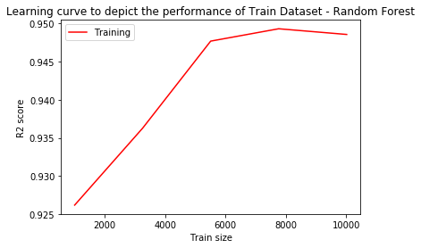

```python
train_scores_m = np.mean(train_scores, axis=1)
test_scores_m = np.mean(test_scores, axis=1)
plt.figure()
plt.plot(train_sizes, train_scores_m , color='r', label='Training')
plt.title("Learning curve to depict the performance of Train Dataset - Random Forest")
plt.legend()
plt.xlabel('Train size')
plt.ylabel('R2 score')
```

```
Text(0,0.5,'R2 score')
```

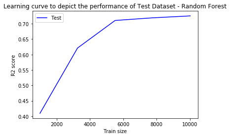

```python
plt.figure()
plt.plot(train_sizes, test_scores_m, color='b', label='Test')
plt.title("Learning curve to depict the performance of Test Dataset - Random Forest")
plt.legend()
plt.xlabel('Train size')
plt.ylabel('R2 score')
```

```python
import xgboost as xgb
from sklearn.metrics import r2_score

xgb_model = xgb.XGBRegressor()
scores = cross_val_score(xgb_model, X,y,cv=5, scoring = 'r2')
print (scores.mean())
```

[output not shown]

[output not shown]

[output not shown]

[output not shown]

```
[23:16:55] WARNING: C:/Jenkins/workspace/xgboost-win64_release_0.90/src/objective/regression_obj.cu:152: reg:linear is now deprecated in favor of reg:squarederror.
0.7209386675865265
```

```python
train_sizes, train_scores, test_scores = learning_curve(xgb.XGBRegressor(),X,y,cv=5,scoring='r2',n_jobs=-1,error_score = 'raise')
```

```
Text(0,0.5,'R2 score')
```

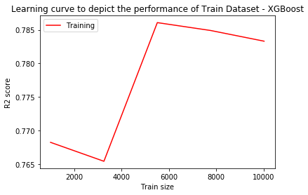

```python
train_scores_m = np.mean(train_scores, axis=1)
test_scores_m = np.mean(test_scores, axis=1)
plt.figure()
plt.plot(train_sizes, train_scores_m , color='r', label='Training')
plt.title("Learning curve to depict the performance of Train Dataset - XGBoost")
plt.legend()
plt.xlabel('Train size')
plt.ylabel('R2 score')
```

*f Test dataset evaluation* The plot for the test dataset evaluation is as shown and it shows that at all times, the accuracy is lower than training dataset. But, initially, the accuracy is very low and gradually it starts to increase as the train_size increases. As it can be seen, the training set accuracy stays approx around 77, and test set stays around 70. Hence, they are still in the comparable range.

```
Text(0,0.5,'R2 score')
```

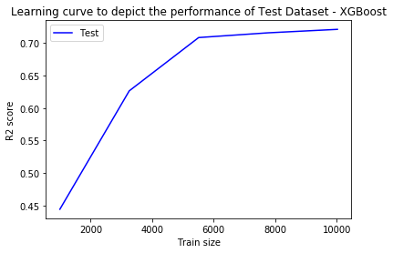

```python
plt.figure()
plt.plot(train_sizes, test_scores_m, color='b', label='Test')
plt.title("Learning curve to depict the performance of Test Dataset - XGBoost")
plt.legend()
plt.xlabel('Train size')
plt.ylabel('R2 score')
```

*g Tune the parameter*

A gridSearchCV is used to tune the hyper parameters of XGBoost, for determining better performance. Hence, to tune the hyper parameters, a few were selected to pass in the parameter grid, from which grid search selected the best possible values for those. Below obtained are the best values. And, once we use those values in the cross-validation of XGBoost, we get an accuracy of around 74.2, which is an increase of around 2%. Hence, we can tune the parameters using GridSearchCV, and it can hence improve the model.

```python
from sklearn.model_selection import GridSearchCV

parameters = {'learning_rate': [0.05,0.1],
              'max_depth': [1,5],
              'n_estimators': [100,300,500]}

xgb_grid = GridSearchCV(estimator=xgb.XGBRegressor(), param_grid = parameters, cv=5, n_jobs =-1, scoring='r2', verbose = 3)
grid_result = xgb_grid.fit(X,y)

grid_result.best_params_
```

```
Fitting 5 folds for each of 12 candidates, totalling 60 fits
```

```
[Parallel(n_jobs=-1)]: Using backend LokyBackend with 8 concurrent workers.
[Parallel(n_jobs=-1)]: Done  16 tasks      | elapsed:  1.8min
[Parallel(n_jobs=-1)]: Done  60 out of  60 | elapsed:  9.3min finished
```

```
[23:27:55] WARNING: C:/Jenkins/workspace/xgboost-win64_release_0.90/src/objective/regression_obj.cu:152: reg:linear is now deprecated in favor of reg:squarederror.
```

```
{'learning_rate': 0.05, 'max_depth': 5, 'n_estimators': 300}
```

```python
xgb_params = grid_result.best_params_

#xg_reg_opt = xgb.XGBRegressor(colsample_bytree= xgb_params['colsample_bytree'],gamma = xgb_params['gamma'],learning_rate = xgb_params['learning_rate'],
#                         max_depth = xgb_params['max_depth'], min_child_weight = xgb_params['min_child_weight'],n_estimators = xgb_params['n_estimators'],
#                         subsample= xgb_params['subsample'])
xgb_reg_opt = xgb.XGBRegressor(learning_rate = xgb_params['learning_rate'],
                         max_depth = xgb_params['max_depth'],n_estimators = xgb_params['n_estimators'])


scores = cross_val_score(xgb_reg_opt, X,y,cv=5, scoring = 'r2')
print (scores.mean())
```

[output not shown]

[output not shown]

[output not shown]

[output not shown]

```
[23:31:16] WARNING: C:/Jenkins/workspace/xgboost-win64_release_0.90/src/objective/regression_obj.cu:152: reg:linear is now deprecated in favor of reg:squarederror.
0.7424840688928813
```

*h Bonus* Tried to use relief feature selection, but could not solve the error.

```python
from sklearn.pipeline import make_pipeline
from skrebate import ReliefF
from sklearn.model_selection import cross_val_score

X = X.reset_index(drop=True)
y = y.reset_index(drop=True)

clf = make_pipeline(ReliefF(n_features_to_select= 100, n_neighbors=100),
                    RandomForestRegressor(n_estimators=100))

clf.fit(X_train,y_train)
```

[output not shown]

**References**

1. https://scikit-learn.org/stable/modules/generated/sklearn.metrics.r2_score.html
2. https://machinelearningmastery.com/evaluate-gradient-boosting-models-xgboost-python/
3. https://seaborn.pydata.org/
4. https://jakevdp.github.io/PythonDataScienceHandbook/04.14-visualization-with-seaborn.html
5. https://stackoverflow.com/questions/36973387/accessing-first-column-of-pandas-value-counts
6. https://medium.com/@aravanshad/gradient-boosting-versus-random-forest-cfa3fa8f0d80
7. https://scikit-learn.org/stable/modules/cross_validation.html
8. https://scikit-learn.org/stable/auto_examples/model_selection/plot_learning_curve.html#sphx-glr-auto-examples-model-selection-plot-learning-curve-py
9. https://www.kaggle.com/omarito/gridsearchcv-xgbregressor-0-556-lb
10. https://www.analyticsvidhya.com/blog/2019/04/predicting-movie-genres-nlp-multi-label-classification/
11. https://stackoverflow.com/questions/37646473/how-could-i-do-one-hot-encoding-with-multiple-values-in-one-cell
12. https://scikit-learn.org/stable/modules/generated/sklearn.preprocessing.MultiLabelBinarizer.html
13. https://www.kaggle.com/stuarthallows/using-xgboost-with-scikit-learn
14. https://stackoverflow.com/questions/27018622/pandas-groupby-sort-descending-order
15. https://stackoverflow.com/questions/8689795/how-can-i-remove-non-ascii-characters-but-leave-periods-and-spaces-using-python
16. https://github.com/EpistasisLab/scikit-rebate